# Cognitive Psychology and Its Implications.Anderson2010.7e.认知心理学及其启示

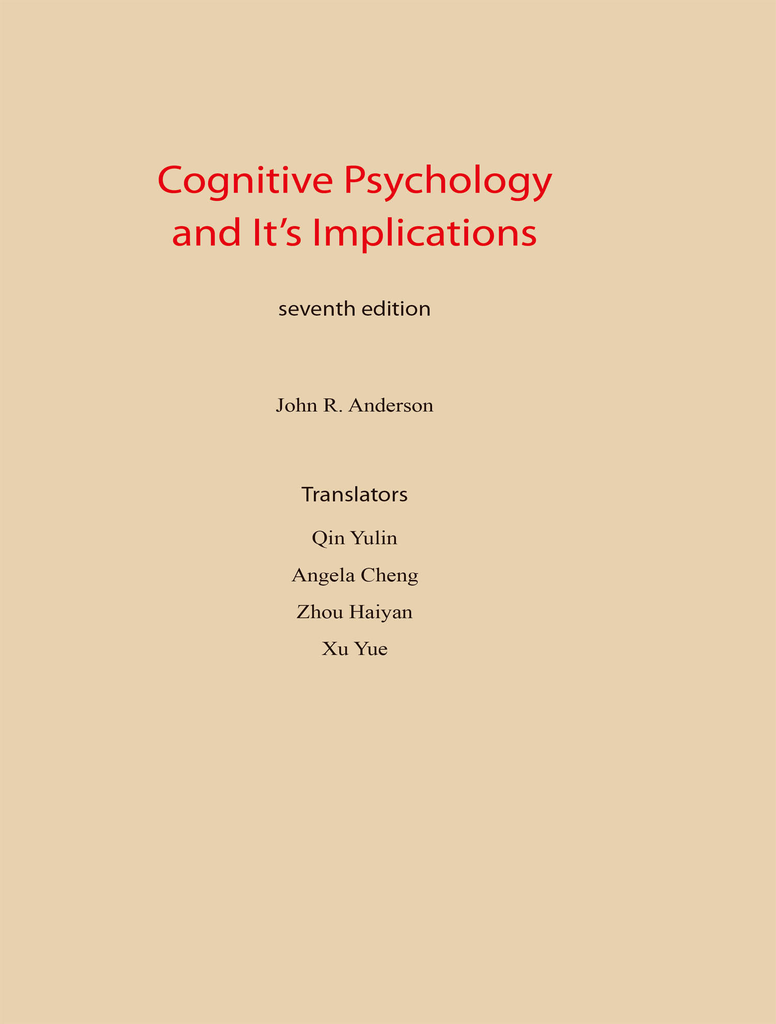

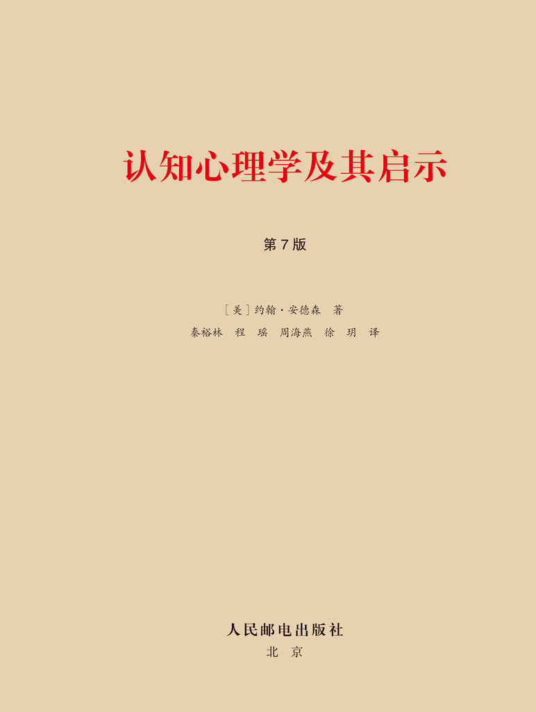

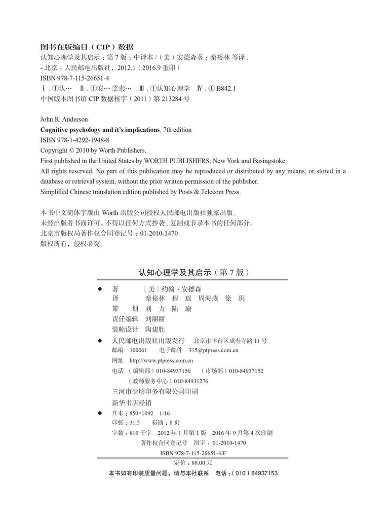

[figure not shown]

彩色插页1.1 布罗德曼（Brodmann，1909）根据细胞结构和排列的不同，将人的大脑皮层分为52个不同的脑区。

[figure not shown]

彩色插页3.1 希罗利姆斯·博施（Hieronymous Bosch）的《人间乐园》。这幅画为视觉注意提供了许多的选择。（资料来源：Corbis Picture Library）

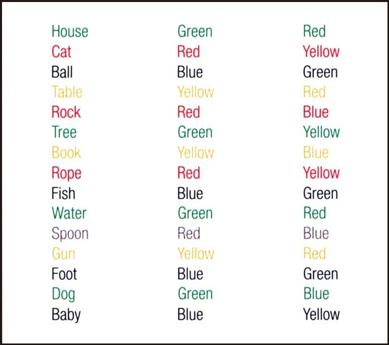

彩色插页3.2 斯特鲁普任务中所用的刺激。尽快说出每列单词的颜色。

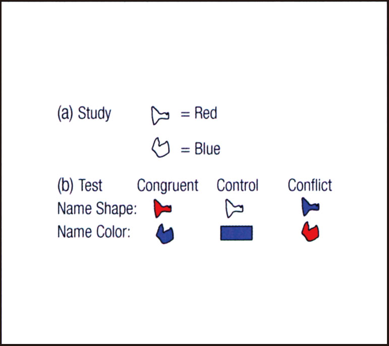

彩色插页3.3 在麦克劳德和邓巴（MacLeod & Dunbar，1988）的实验中，被试可能看到的材料示例。

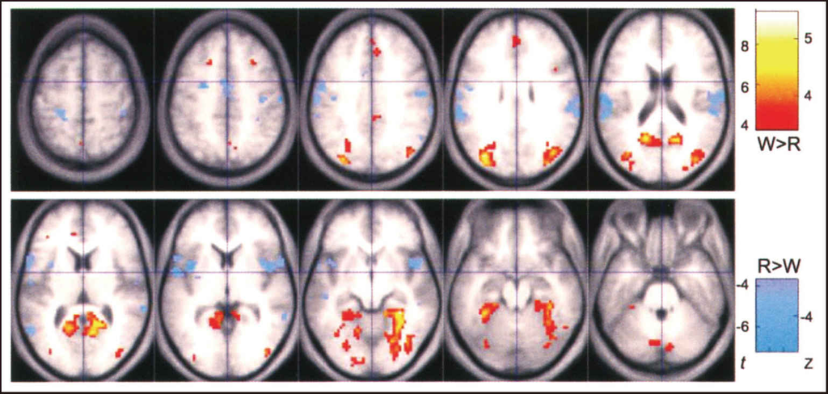

彩色插页4.1 哈特利等人的研究（Hartley et al.，2003）结果。红色区域是在俯瞰图任务中比在行进图任务中表现出更强激活的脑区（W＞R），蓝色区域是在行进图任务中比在俯瞰图任务中表现出更强激活的脑区（R＞W）。

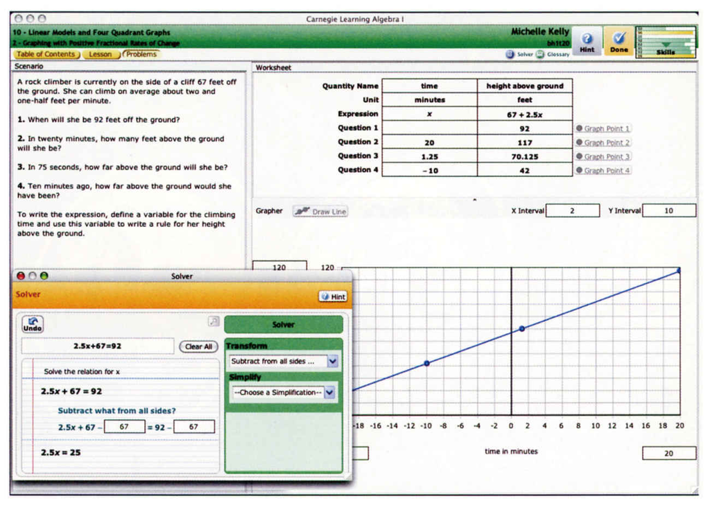

彩色插页9.1 代数认知家教系统的屏幕截图。

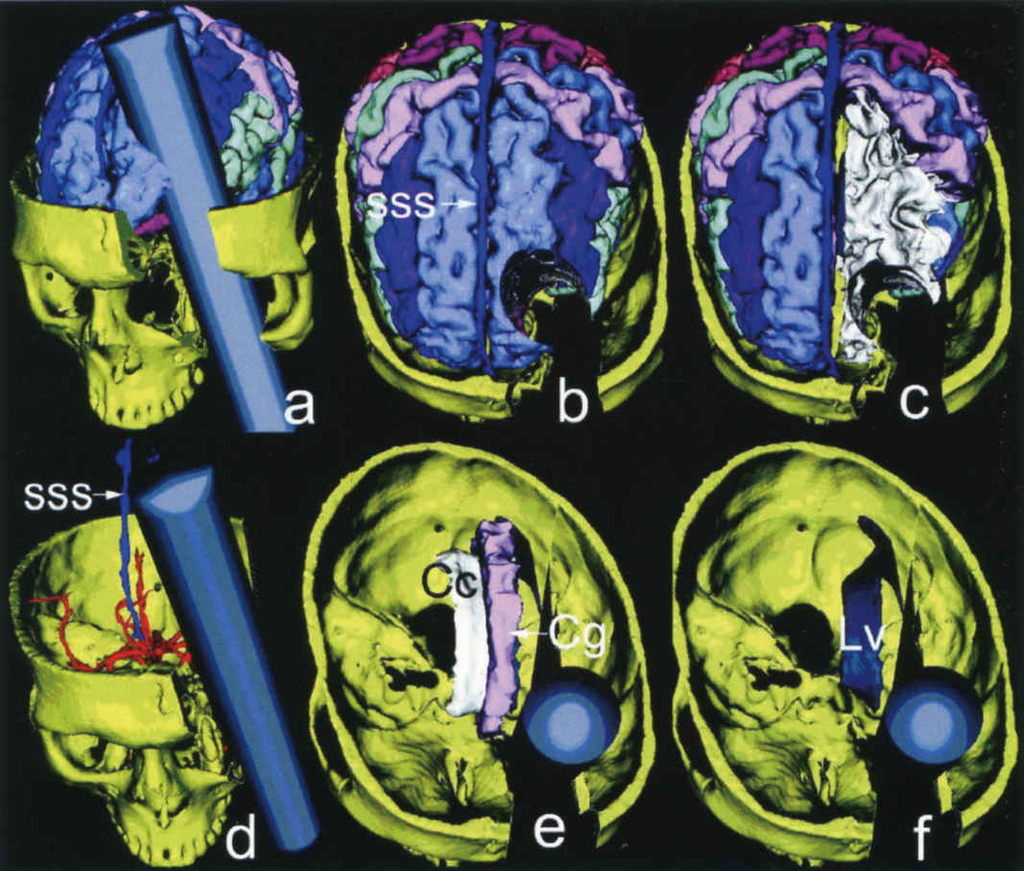

彩色插页11.1 计算机生成的菲尼亚斯·盖奇的脑损伤模型。（a）在原位置的铁棒。（b）将铁棒从大脑模型中去掉之后的洞。SSS，上矢状窦。（c）为了显示出白质，将灰质移走后的模型。（d）铁棒与SSS和其他血管之间的关系。（e）铁棒和扣带回（Cg）之间的关系。（f）铁棒和左侧脑室的关系。

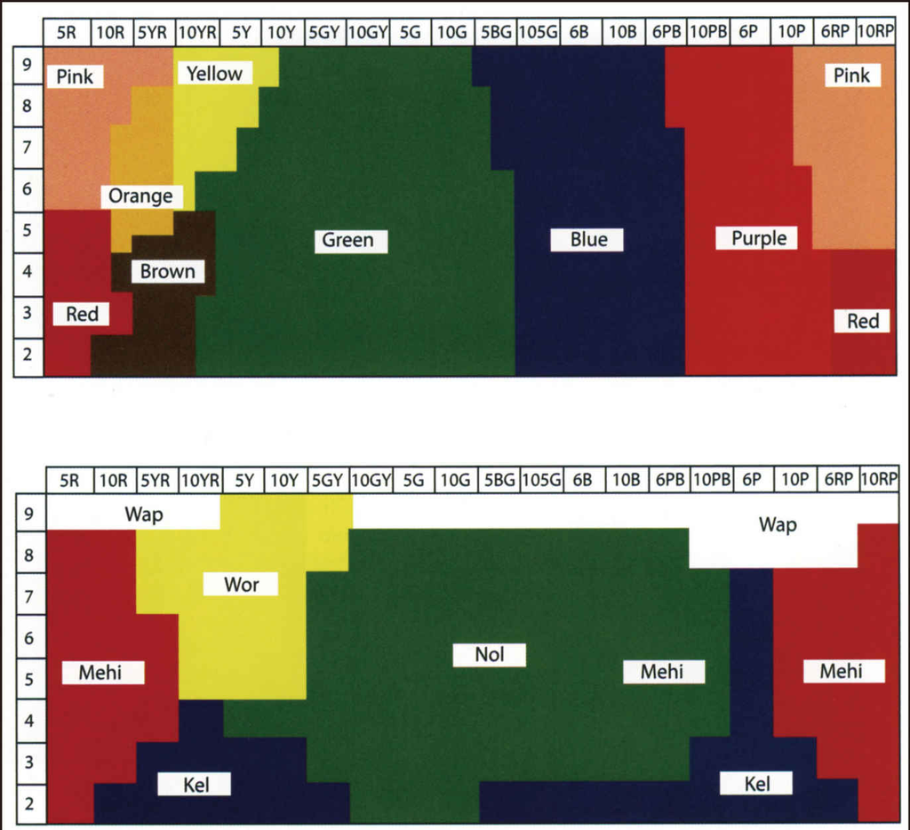

彩色插页12.1 在色调（hue，横轴）和亮度（brightness，纵轴）上变化的160种颜色。（a）英语母语者如何在色谱中划分颜色；（b）贝林姆母语者如何在色谱上划分颜色。（资料来源：Kay & Regier，2006）。每种颜色所对应的空间由该颜色的最佳实例表示。

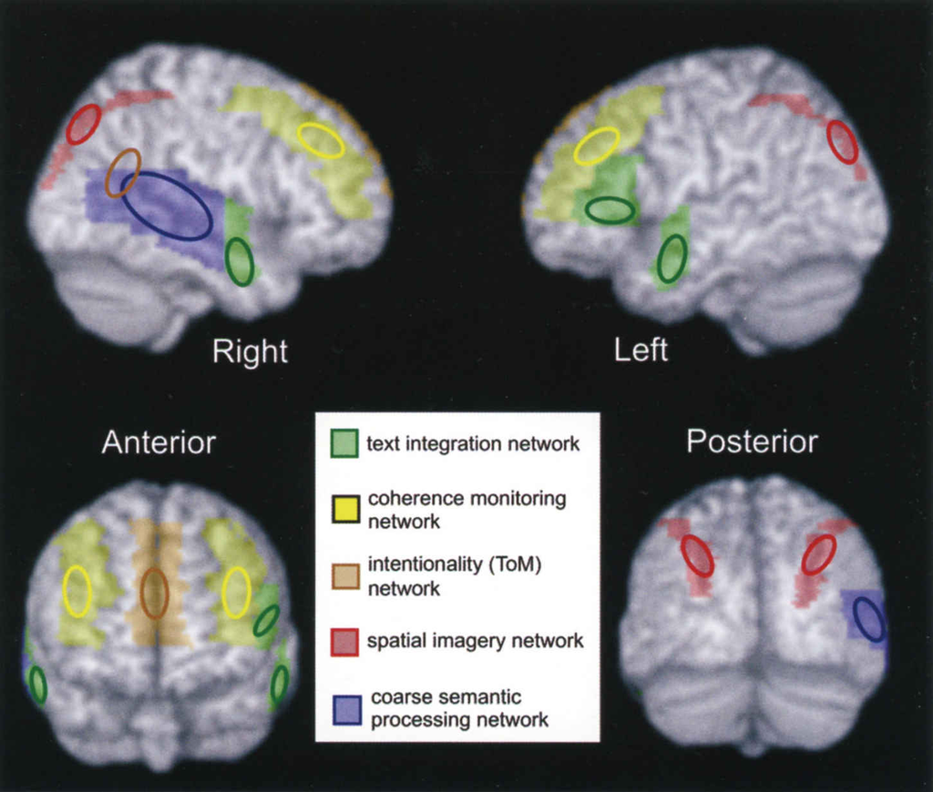

彩色插页13.1 语段加工相对应的网络的概略图。颜色加深的区域表示正文中描述的表层解剖结构。彩色的椭圆标明在解剖区域上的粗略定位。

# 内容简介

本书自1980年第一版出版以来，每五年更新一版，是认知心理学领域的经典教材。该第7版于2010年出版，是最新版。

本书系统地将传统认知心理学与脑功能成像技术的应用相结合，侧重于人脑的认知研究，并通过“启示”将研究与我们的生活联系起来。作者以流畅的语言，深厚的学术功底，引领读者进入认知心理学领域。

本书共14章，第1章介绍了认知心理学的发展和思路以及人类认知的神经基础，第14章介绍了认知的个体差异。其余12章分别探讨了知觉、注意、心理表象、知识表征、记忆、问题解决、推理、判断和决策、语言等各个人类认知领域的信息加工过程，其中每两章为一个专题，共六个专题。同时，吸纳了认知神经科学领域内的研究成果，分析了认知的神经基础，内容详尽、深入，具有相当的前沿性。

本书是心理学、计算机等专业的教师、学生和研究人员系统地了解认知心理学及其最新发展的不可多得的教材。

# 中文版前言

很荣幸地看到我的教科书被翻译成了中文。在我投身于这个领域的期间，认知心理学正经历着重要的成长。我则尽力地把不断出现的最新发展反映在本教材的历次版本之中。认知心理学研究的更加国际化是这个领域成熟的标志之一。在最近对中国的访问中，我看到中国正在进行的各种非常有魅力的研究课题给我留下了深刻的印象。我希望本书的翻译能够为更多的中国认知心理学家的发展作出贡献。我也希望在本书将来的版本中介绍他们的工作。

我特别愉快地参与了秦裕林的翻译工作。在这个过程中，他发现了英文版本中的许多小错误，使我能够通知我的出版商给予纠正，英文版也因此得到了改进。现在的英文版或许可以看成是更加准确的中文版的英译本了。

约翰·安德森

卡内基-梅隆大学

理查德·金·梅隆心理学和计算机科学教授

美国宾夕法尼亚州匹兹堡，邮编15213

2011年4月8日

# Foreword

It is an honor to see my textbook translated into Chinese.Cognitive Psychology has undergone major growth during the time I have been in thefield．In the various editions of the textbook I have tried to reflect the newest developments．As one sign of its maturation research in Cognitive Psychology has become more international．During my recent visit to China I was deeply impressed by the fascinating research questions I saw being pursued there．I hope the translation of this book can contribute to the development of more cognitive psychologists in China．I also hope I will be describing their work in further editions of the book．

It has been a particular pleasure to work with Yulin Qin on the translation．During the process，he uncovered many subtle flaws with the English version and I have been able to advise my publisher of the corrections．So the English version has improved as well．One might regard it now as the English translation of a more accurate Chinese version．

John R．Anderson

Richard King Mellon Professor

of Psychology and Computer Science

Carnegie Mellon University

Pittsburgh，PA 15213

April 8，2011

# 译者的话

这是一部著名的美国认知心理学教科书的最新版本（2010年第7版）的中文版。在一定意义上，认知心理学可以与物理学相比较。物理学采用实证的方法研究物质世界最基本的物质运动规律；认知心理学采用实证的方法研究精神世界的最基本的物质运动规律——人类思维（包括感知）的信息加工过程。

爱因斯坦有这样一句话：“可以说‘世界的永恒之谜是它是可理解的’”（“One may say‘the eternal mystery of the world is its comprehensibility.’”，Albert Einstein（1936）．Physics and reality．Journal of the Franklin Institute．221（3）：349-382）。认知心理学就是试图用实证的方法（而不是抽象的思辨），通过逐步认识人脑的具体信息加工过程去揭开这个谜底，去逐步理解人为什么能够理解世界和怎样理解世界。本书就体现了人类当今在这方面的努力。

本书的作者，美国著名的认知心理学家，约翰·安德森（John R．Anderson）是美国卡内基-梅隆大学（Carnegie Mellon University）心理学系和计算机科学系梅隆教授，美国科学院院士，曾任美国科学院心理学部（Psychology Section）2001～2004届主席，认知科学学会1988届主席，曾获美国心理学会杰出科学职业奖（American Psychological Association's Distinguished Scientific Career Award，1994）、鲁姆哈特奖（2004）、实验心理学杰出成就奖（2005）、荷兰皇家科学院首届海涅肯（Heineken）认知科学奖（2006）、和富兰克林计算机与认知科学奖（2011）等重大奖项。

目前在国内，包括人民邮电出版社新曲线公司，已经出版了一些非常好的认知心理学教材，为什么还要引进这部教材？一个最一般的理由是教材的多样性：不同的教材有不同的视角和取舍材料的考量，适合于不同的老师、学生和科研人员的需求。具体说来，这部教材有如下特点：

1．注意引导学生将书中系统讲解的理论知识应用到自己的学习和工作中去。

安德森一贯认为，联系实际应用不仅能促进实际工作，而且能检验和改进理论。在作者的早期理论框架建立时，他就开发了著名的计算机辅助教学系统（今天的智能家教的前身）。近年来，他的ACT-R模型也已经在工业和军事的多个领域获得了种种不同的应用。

作者的这一思想也体现在本书的编写中。这不仅反映在书名和“启示”专栏的设置上，而且也体现在本书各章的具体论述中。例如，在本书的第1章，作者就介绍了根据认知心理学理论发展出来的学习教科书的有效方法，供读者学习本书时用。第5章中，在介绍关于意义记忆的理论研究以后，作者结合自身在大学二年级时的实际教训，介绍了帮助记忆单词的方法。

建议每一位学生在学习本书的时候把自己放进去思考，包括质疑书中讲的与自己的经验是否一致（不一致的地方常常是深入学习，甚至是新的研究的起点），也包括思考如何根据当代认知心理学的发现促进自己的学习与工作。一个好的学生通过对这本书的学习，不但可以比较完整地掌握当代认知心理学的基本知识，而且还能够提高和改进自己的学习、记忆方法，增强推理和解决问题的能力。

2．与认知心理学的发展趋势一致，本书注重高层次认知过程，包括知识的表征、记忆与学习、问题解决、判断推理以及语言。

本书一共14章。第1章介绍了认知心理学的发展和思路以及人类认知的神经基础，第14章介绍了认知的个体差异。其余的12章分为6个单元，有5个单元分别讲述上面所列的高层次认知内容。其中的2个单元中有3章与记忆与学习有关，其系统和深刻细致程度远远超出国内外的许多其他认知心理学教材。这固然是因为记忆是一切高层次认知的基础，同时也因为作者本人正是国际公认的该领域的大师之一。

当然，或许也因为这个原因，对于一位只对感觉、知觉有兴趣的读者，本书未必是首选对象。

3．强调了认知活动的神经基础

如本书第1章所示，安德森认为认知神经科学的迅速发展，使认知心理学领域正处在可能像认知革命那样的意义重大的变革之中。从2000年起，安德森系统地开展了用fMRI（功能性磁共振成像）探讨人的认知体系结构（cognitive architecture）的神经基础的研究，包括开拓了用计算认知模型预测相关脑区的BOLD效应（血氧水平依赖效应）的方法。作为这些思想和实践的反映，本书从2005年第6版起，大量引用了认知神经科学的成果和证据。在本版上述12章的每一章第一节，作者都介绍了与这一章所讨论问题有关的脑区。这是本书自上一版开始，与以前版本最大的区别之一，也是本书与许多其他认知心理学教材的明显区别之一。译者希望，本教科书的这个特点，将有助于国内认知心理学界将脑功能成像方法广泛用于认知心理学研究的迅速展开。

4．不是简单地罗列素材，而是突出了提出问题和解决问题的思路。

译者相信，这一点对培养学生的独立思考和开拓研究能力极为重要。可以说，认真学习本书，就是在向国际级大师学习科学研究的思路和方法。

5．行文通俗易懂，内容丰富，取材精当。

这个特点使得本书不仅适合于认知心理学专业和其他心理学专业的学生、教师和研究人员；适合于计算机科学、人工智能等方面的学生、教师和研究人员；它也能让从事经济学、语言学、哲学等社会科学方面的科研人员和一般读者从本书得到启迪和教益。

目前在人文社会科学中，认知心理学尚不能像物理学在自然科学那样处于基础学科的地位。正如本书作者所指出的，原因是认知心理学还太年轻，在当代认知心理学诞生的20世纪50年代，社会科学的绝大多数分枝早已是根深叶茂了。但是，作为从各种不同的角度反映人类的行为和思维的社会科学的许多分枝，或早或晚地将其理论基础奠定在对人类思维的信息加工过程的研究之上则是一个大的方向。行为经济学、神经经济学、神经社会学、认知语言学、认知人类学、认知政治学和神经法学（Neurolaw）等的出现就是例子。年轻的学者可望在这个方向做出开拓性的贡献。

1988年，本人作为学生曾选修了由作者亲自讲授的本书第2版的课程。2000年我参与到作者将ACT-R和fMRI相结合的研究项目组以后，又在2003年旁听作者讲解本书的第5版。在组织翻译这一版时，我能深切地感到这些版本之间的变化之大，以及它们所反映的认知心理学领域的发展之快。

尽管先贤们在翻译经典世界名著时的‘信达雅’水平我们可能难以企及，但是作为教科书的翻译，我认为，至少应当是用比较通顺的中文尽可能准确明了地传达原著的原意。为了实现这个目标且能尽快出版，我们的两个做法是：（1）与原作者紧密联系。本书的中文版，在很大程度上，是原作者和译者共同工作的结果。除了口头讨论以外，光是通过电子邮件向原作者请教和讨论书中有关的地方就超过400处，其中的小部分显著地反映在【译注】之中。（2）多人多重翻译，反复研磨。原来计划翻译出版的是本书的2005年版本——第6版，第6版有13章，第一轮翻译的分工是：第1～3章，丁守一、秦裕林；第4～6章，徐玥；第7～9章，李艳洁、周海燕；第10～13章，周海燕。在第一轮翻译的基础上，秦裕林将全书再翻译一遍，包括向原作者请教，程瑶（Angela Cheng）则通篇梳理全书的中文；最终，再由秦裕林最后定稿。当第6版的翻译工作接近尾声时，2010年原文第7版在美国出版，为了能够紧跟原版的更新步伐，尽快地反映认知心理学的最新发展面貌，出版社决定立即着手最新版的翻译工作。第7版扩充为14章，新增内容的第一轮翻译由徐玥完成第1～7章，周海燕完成第8～14章。秦裕林和程瑶则在此基础上，将全书再翻译一遍。因此本书的中文翻译工作是几经研磨而成的。

虽然尽了种种的努力，但由于原著所涉及范围的宽广和译者学识能力所限，译文中仍然会存在差错及不当之处。此外，如所有译过教科书的人都了解的那样，给有些名词术语选择恰当的中文词是相当困难的一件事。为了更准确地反映原意，本书对个别术语选择了与其他教材不同的译法，这些都已经加注说明。本书还出现了其他教材上没有的术语，对这些术语的译法是否恰当，欢迎读者与我们讨论。因为最后的文字是我定下来的，译文中出现的问题当由我完全负责。恳请读者一旦发现有差错及不当之处，或对本书有任何意见建议，直接发电子邮件至yulinqin@gmail.com，以便更正。在此预致谢忱。

最后，我要对北京工业大学国际网络智能（WIC）研究院的支持表示感谢，研究院致力于网络智能和人脑智能相结合的研究的需要，促进了本书的翻译工作；感谢原著作者安德森教授给予中文版翻译工作的积极配合；特别要感谢的是新曲线公司的鼎力支持，感谢陈浩莺、刘丽丽两位编辑的辛勤工作。

秦裕林

# 目录

内容简介

中文版前言

Foreword

译者的话

序言

第1章 认知的科学

动机

知性的好奇

对其他领域的启示

实际应用

认知心理学的历史

早期史

启示：认知心理学告诉我们怎样才能有效地学习

德国的心理学：聚焦于内省观察

美国的心理学：聚焦于行为

认知革命：人工智能、信息论和语言学

信息加工分析

认知神经科学

信息加工：互通讯息的神经元

神经元

信息的神经表征

脑的结构

功能定位

拓扑组织

认知神经科学的方法

用fMRI研究解方程

第2章 知觉

视觉信息加工

脑的视知觉

早期视觉信息加工

视细胞中的信息编码

深度与表面知觉

物体知觉

视觉模式识别

模板匹配模型

特征分析

启示：区分人类与BOT

物体识别

脸的识别

言语识别

言语的特征分析

类别性知觉

情境与模式识别

综合情境与特征信息的马萨罗FLMP模型

情境与识别的其他例子

结论

第3章 注意与操作

顺序瓶颈

听觉注意

过滤器理论

衰减理论与后期选择理论

视觉注意

视觉注意的神经基础

视觉搜索

捆绑问题

视野忽视

基于物体的注意

中枢注意：选择所要追随的思路

启示：为什么边开车边使用手机是危险的行为

自动化：通过练习而精通

斯特鲁普效应

前额的执行控制部位

结论

第4章 心理表象

言语表象与视觉表象

视觉表象

表象扫描

大小的视觉比较

视觉表象类似于视知觉吗

视觉表象与脑区

表象既包括空间成分又包括视觉成分

认知地图

空间的自我中心和他我中心表征

地图曲解

将文字转换成表象

结论：视觉知觉与视觉表象

第5章 知识的表征

知识及相关脑区

对事件意义的记忆

言语信息的记忆

视觉信息记忆

细节与意义的保持

意义记忆效果好的启示

启示：记住词汇表的记忆术

命题表征

命题网络

通道无关符号系统与知觉符号系统

具身认知

概念知识

语义网络

图式

图式的心理学真实性

类别成员的隶属程度

事件概念

抽象理论和实例理论

脑中的天然类别

结论

第6章 人类的记忆：编码与储存

记忆与脑

感觉记忆短暂地保存信息

视觉感觉记忆

听觉感觉记忆

短时记忆理论

工作记忆保存执行任务所需的信息

巴德利的工作记忆理论

额叶皮层与灵长类的工作记忆

激活与长时记忆

激活计算的例子

扩散激活

练习与记忆强度

学习的幂定律

幂定律的神经基础

影响记忆的因素

增细加工

学习课本教材的技巧

有意义与无意义的增细加工

启示：地点记忆法如何帮助我们组织记忆

伴随学习与有意学习

闪光灯记忆

结论

第7章 人类的记忆：保持与提取

记忆真的被遗忘了吗

保持函数

干扰如何影响记忆

扇面效应：事实网络

对先前存在的记忆的干扰效应

关于干扰和消退的争论

冗余防止干扰

提取和推断

似真提取

增细加工和推断重构的交互作用

启示：广告商如何利用认知心理学的知识

目击者证言和关于虚假记忆的争论

虚假记忆和大脑

联想结构和提取

编码情境效应

编码特异性原理

海马结构和遗忘症

内隐记忆与外显记忆

正常被试的内隐记忆和外显记忆

程序性记忆

结论：人脑中记忆的各种类型

第8章 问题解决

问题解决的本质

从比较的角度看问题解决

问题解决的过程：问题空间和搜索

问题解决的算子

算子的习得

类比与模仿

从进化和脑的视角看类比与模仿

算子选择

差异降低法

手段—目的分析

河内塔问题

目标结构与前额皮层

问题表征

正确表征的重要性

功能固着

定势效应

酝酿效应

顿悟

结论

附录：解答

第9章 专业技能学习

脑随着技能的获得而发生改变

技能习得的一般特征

技能习得的三个阶段

学习的幂定律

专业技能的本质

程序化

技法学习

策略学习

问题感知

模式学习和记忆

启示：计算机成为国际象棋专家的方式与人类不同

长时记忆和专业技能

有目的练习的作用

技能的迁移

相同要素说

教育启示

智能家教系统

结论

第10章 推理

推理和脑

对条件命题的推理

由条件论据判定结论

在更大的背景中由条件论据判定结论

沃森选择任务

条件命题的许可解释

条件命题的概率解释

关于连接词‘如果’的最后思考

演绎推理：关于量词的推理

直言三段论

氛围假说

氛围假说的局限性

加工解释

归纳推理和假设检验

假设形成

假设检验

科学发现

启示：一个90％的结果有多大的说服力

结论

第11章 判断与决策

人脑与决策

概率判断

贝叶斯定理

对基础比率的忽视

保守主义

经验导致遵从贝叶斯定理

概率判断

再认启发式的适应性本质

决策

框架效应

启示：为什么青少年更容易做出错误的决策

主观效用和主观概率的神经表征

结论

第12章 语言结构

语言与脑

语言学领域

生成性和规则性

语言直觉

能力和操作

句法形式结构

短语结构

言语的停顿结构

言语错误

转换

人类语言为什么如此特别

启示：猿的语言和实验伦理问题

语言和思维的关系

行为主义观点

沃夫的语言决定论假说

语言取决于思维吗

语言的模块性

语言获得

关于规则和过去式的争议

输入的性质

语言获得的关键期

语言通则

对于转换的约束

参数设定

结论：语言的独特性：总结

第13章 语言理解

脑和语言理解

语法分析

成分结构

解释的即时性

句法结构的加工

语义考虑

句法和语义的整合

句法和语义加工的神经标志

歧义

暂时性歧义加工的神经标志

词汇歧义

模块性加工与交互加工的比较

启示：智能话匣子

语用

跨桥推理与增细推理

所指推理

代词的所指

否定

文本加工

文本结构和记忆

文本表征的层次

结论

第14章 认知的个体差异

认知发展

皮亚杰的发展阶段

守恒

什么在发展

经验论者和先验论者的争论

增强的心理能力

增长的知识

认知和老龄化

认知发展小结

认知的心理测量学研究

智力测验

启示：智商决定人生的成功吗

因素分析

推理能力

语言能力

空间能力

心理测量学研究的结论

结论

专业术语表

主题索引

参考文献

# 序言

这 是本教材的第7版，每五年更新一次的最新版本。每次坐下来为新的一版写序言时，我都会对认知心理学领域的进展有更深的感触。当我着手写作1980年的第1版时，认知心理学已经经历了30年的令人惊叹的发展。在20世纪50年代，一些真正的先驱者打破了行为主义的传统，为认知心理学奠定了基础。在20世纪60年代，心理学家们努力为这个新领域建立实验范式和理论模型。他们的成就经常被恰当地称为“认知革命”（“cognitive revolution”）。当我于20世纪70年代初期进入该领域时，我从前面这两个十年的成果中受益颇多。20世纪70年代，认知心理学的研究极其繁荣。当那个十年接近尾声时，这个领域明显地有了更加广阔和更加展开了的层次清楚、条理连贯的可以在教科书中交流的结构。

第1版诞生于1980年，在时间上处于1950年认知革命的开端和2010年第7版出版的正中间。以2009年的视角（此时我正在写这篇前言），我们可以相当清楚地看到该领域加速发展的科学进程。自第1版以来，这本教材所涵盖的每个心理学研究主题都无一例外地有了难以想象的大幅度发展。在描述该领域的发展过程时，我们不得不使用对抗式语言——“理论1提出了一个主张，但是理论2指出理论1是错的，一个决定性的实验显示理论2是正确的，但是随后，又有证据表明理论1……。”本教材无意于把注意力集中在这些“理论碰撞”之上，尽管不提及有些争论就无法如实地叙述该领域。我们并不是要忽视这些争议，而是要把重心放在更具说服力的方面——我们在理解人类心理运作方式方面所逐步积累起来的巨大进步。

认知领域的教材通常都非常依赖文献中的种种特定实验研究，以此来阐述对人类心理的最新认识，本书也不例外。所以，本书的参考文献也可以看成是对该领域知识增长的度量。下面的插图所示的是本版所引用的各个时期的参考文献的数量，以“十年”为单位。虽然本版参考的最后十年（21世纪前10年）的文献还不够完整，但该图已经可以很好地展现出认知心理学的发展概貌了。认知领域的知识从20世纪50年代起开始增长，而且是加速增长。因为我觉得很有必要去引用至今仍起作用的经典文献，本书所引用的大多数文献都出现于第一版诞生之后的事实，则是该领域知识加速增长的证明。

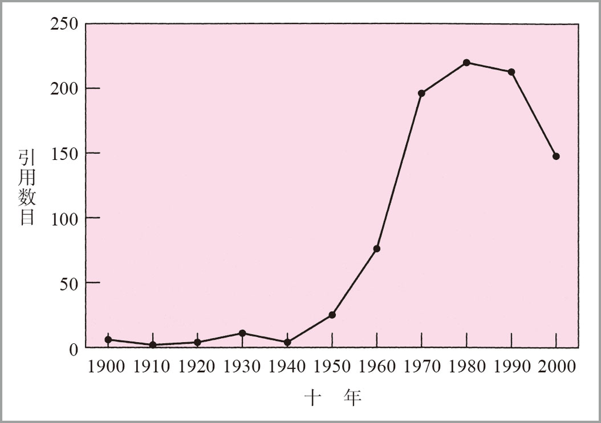

1980年以来，认知心理学的发展主要有两个维度，这些发展都体现在本教材不断更新的版本内容上。第一个维度是对人类认知的各个领域的更加精细和更加深入的理解，包括对许多早期观点的实质性修正。第二个维度是认知神经科学通过研究人脑来理解心理的能力的突飞猛进。现在，我们来看看本书的第7版，它似乎是和第1版非常不同的一本书。本版介绍的有些内容是我在1980年时完全不可能想象到的。

第7版比第6版增加了很多内容。例如：

- 新的神经科学的方法在视觉注意、心理表象和决策等领域的应用。
- 在记忆与情绪、科学发现和第二语言获得等许多不同主题上的新结论。
- 在视觉、博弈和语言加工等方面，对人工智能和人类智能的进一步比较。
- 将决策和推理分成了两章，这个变化反映了这些领域的新研究成果，包括认知神经科学的贡献。

需要注意的是，伴随着上面最后一项内容的更新，现在从第2章到第13章每两章组成一个专题，一共有六个专题：知觉和注意、知识表征、记忆、问题解决、推理和决策、语言。虽然不同的老师有他们自己组织教材的方法，但是在我的课堂上，我发现这样的组织有助于把课程组织成数目较少的单元，以便学生清楚地了解自己学到了什么地方。

我还想强调本版所具有的两个新特色，它们激励了我的写作热情，我亦希望本教材因此能更加吸引读者的兴趣和关注：

- “启示”专栏，它使本书的最初目标变得更加明晰：证明认知心理学与我们生活的许多方面以及我们对自身的认识息息相关。
- 每章最后的思考题，其中有些是本领域的前沿问题，它考查了读者是否深入掌握了本章内容。

许多其他的新特色是在我的编辑埃里克·吉尔戈（Erik Gilg）和开发编辑瓦莱丽·雷蒙德（Valerie Raymond）的建议下增加进来的。例如，增加了彩色插页来呈现确实需要用颜色来表达的画面。如果你手里有这本书（我还没有），大多数的变化应该是显而易见的。他们还做了很多工作使得本教科书的版式体现了21世纪的时代气息。

以下为致谢部分，包括作者对本书的其他出版、编辑和工作人员的致谢；对他的研究助手的致谢；对他二十出头的小儿子提供的诸如什么是当代青年所知与所不知的信息，使得本教材更能与年轻读者沟通表示感谢；对提供意见和建议的12个院校的评审者的致谢。最后，感谢98位读过前6版并提供过建议的人，其中包括安德斯·埃里克森（K．Anders Ericson），迈克尔·加扎尼加（Michael．Gazzaniga），戴维·克莱尔（Dave．Klahr），史帝文·科斯林（Steve Kosslyn），杰·麦克莱兰（Jay McClelland），艾伦·纽厄尔（Al .Newell），迈克·波斯纳（Mike Posner），特里·塞诺斯基（Terry Sejnowski）等知名教授以及作者的夫人，美国卡内基-梅隆大学心理系琳恩·雷德（Lynne Reder）教授。具体从略。

# 第1章 认知的科学

我 们所属的物种被称为智人（Homo sapiens ），或者叫“智慧的人”。这个称谓反映了一个普遍的信念——将人类从其他动物中区分开来的正是我们卓越的思维过程。今天，我们都知道脑是人的心理活动器官，但是脑与心理之间的联系并不是一开始就被人们所了解的。例如，基于一种十分错误的联想，古希腊哲学家亚里士多德将心理活动定位于心脏中，他认为脑的功能是用来冷却血液的。认知心理学 （cognitive psychology）是一门探讨心理是如何被组织而产生智能思维，以及心理是如何在脑中实现的科学。本章通过讨论下列问题来介绍一些最基本的概念，作为本书其余章节的准备。

- 为什么要研究认知心理学？
- 认知心理学起源于何时何地？
- 脑中的细胞是如何加工信息的？
- 脑由哪些部分来负责它的各种不同功能？
- 哪些新的研究方法扩展了认知心理学的研究领域？

## 动机

### 知性的好奇

研究认知心理学的一个动力是求知欲，这与激发人们进行任何科学探索的动力完全相同。在这方面，认知心理学家就像一名喜欢鼓捣机器的人想知道钟表是怎么工作的一样。人的心理是一种极具魅力的装置，它展现出令人称奇的智慧和适应能力。而我们通常却察觉不到人的认知的非凡层面。正如我们无法想象使世界各地的新闻事件得以在电视中现场直播需要多么庞大的技术积累一样，人们同样也会忽略，假如要理解这些新闻事件，我们的心理过程需要何等地精妙复杂。我们想了解的就是产生这种复杂精妙的智力的机制。

人脑的内在运作方式远比现代技术中最复杂的系统更加错综复杂。人工智能 （artificial intelligence，AI）领域的研究者们一直在试图开发能使计算机展现智能行为的程序。尽管这个领域是半个世纪以来最活跃的领域之一，并且已经取得了不少令人瞩目的成就，但是，人工智能的研究者们至今仍然无法知道如何开发出能够与人的智能相媲美的程序。没有一个现有的程序具有人类那样回忆事实、解决问题、推理、学习和加工语言的能力。人工智能没能实现人类水平的智能，导致了一些奠基者们的大量反思（例如，McCarthy，1996；Nilsson，2005）。人工智能需要更多地关注人类的思维功能，这种观点正在复兴。

人的智能并没有显示出有任何神秘的东西使我们无法用计算机建立它的模型。以科学发现为例，科学发现通常被认为反映了人类智能的最高成就。科学家被认为实现了直觉的飞跃，使令人困惑的数据得以解释。形成一个新颖的理论既需要伟大的创造力，也需要独特的推理能力。赫伯特·西蒙（Herbert Simon）曾因其在经济学理论方面的建树而荣获了1978年的诺贝尔奖。他付出了生命中的最后四十年研究认知心理学。除了其他方面的贡献外，他集中研究了“从事”科学时涉及的智力过程。他和同事们（Langley，Simon，Bradshaw，& Zytkow，1987）于1987年编制了模拟在科学探索中的问题解决活动的计算机程序。所模拟的科学探索包括开普勒探索行星运动定律和欧姆探索电路定律。这些计算机程序属于最令人赞叹的人工智能的成果之一。此外，西蒙还仔细考查了他本人所做的著名的科学探索的过程（Simon，1989）。在所有的个案中，他发现，科学探索的方法可以用我们在认知心理学中所研究的基本的认知过程来阐明。他写道，这些活动中很多只是熟知的问题解决过程（我们将在第8章和第9章中研究它们）。他还写道：

此外，被认为是从事科学发现这类工作所必需具备的顿悟，则被证明是“识别”这一我们所熟知的过程的同义语。通常用于讨论创造性工作的其他术语，例如“判断力”、“创造力”，甚至“天才”等，看来统统都是没有必要的，或者是，如同顿悟那样，可以用熟知的寻常概念来定义。（p．376）

于是，西蒙得出结论，当我们仔细考察人类智慧时，我们发现它涉及的是基本的认知过程，这些基本的认知过程以复杂的方式一起运作从而产生出灿烂的成果。 <sup>(1)</sup> 本书的大部分篇幅将着重描述我们对这些基本过程的认识。

◎基本的认知过程构成了诸如科学发现那样的伟大的智能成就的基础。

## 对其他领域的启示

对心理学或社会科学的其他领域感兴趣的学生和学者有另外一个理由来关注认知心理学的发展。支配人类思维的基本机制对于理解其他社会科学所研究的行为类型是非常重要的。例如，要理解为什么会发生某种思维障碍（临床心理学）、人在对待别人时或者在群体中会有怎样的行为（社会心理学）、劝说是如何起作用的（政治学）、如何作出经济决策（经济学）、为什么某些组织群体的方法要比其他方法更为有效和稳定（社会学），以及为什么自然语言具有一定的特征（语言学）等问题。因此，认知心理学是所有其他社会科学的基础，就如同物理学是其他自然科学的基础。

尽管如此，许多社会科学在没有认知心理学作基础的情况下就已经发展起来了。两个事实可以说明这一状况。第一，认知心理学领域尚待发展。第二，社会科学的其他领域的研究者们设法寻找了其他的途径来解释他们感兴趣的现象。经济学就是一个有趣的案例。新古典主义经济学统治了上个世纪。它完全忽视了个体 <sup>(2)</sup> 的认知加工过程，并且认为通过假设个体行为是简单地追求财富最大化，就可以预测市场行为。但是，近年来行为经济学开始发展，它强调如果经济学家想要理解市场行为，他们就需要重视个体的有缺陷的决策过程（第11章的主题）。由此，举例来说，人们在使用信用卡时会比使用现金乐于支付更多（Simester & Drazen，2001）。由于认识到了决策心理学对经济学的重要性，认知心理学家丹尼尔·卡尼曼（Daniel Kahneman）于2002年被授予诺贝尔经济学奖，以表彰他和已故的阿莫斯·特韦尔斯基（Amos Tversky）的贡献。

◎认知心理学是其他许多社会科学的基础。

### 实际应用

认知心理学的实践意义是认知心理学研究的另一个关键动机。如果我们确实能弄清楚人们是如何获得知识和智能技艺的，以及人们是如何执行智能行为的，那么，我们就能够相应地改进他们的智能训练和绩效。

事实将证明，认知心理学正在开发的有关心理的知识不论对个人还是对社会都是有益的。我们的许多问题源自我们没有能力处理超负荷的认知需求。当前的信息爆炸和技术革命正在加剧这些问题。虽然认知心理学刚刚开始这方面的研究，但是已经出现了一些直接应用于日常生活的明显而确切的成果。认知心理学已经应用于司法界［例如，关于目击者证词的可靠性研究（Loftus，1996）］、计算机系统设计［例如，关于使用词处理器（Card，Moran，& Newell，1983），或关于网络浏览的研究（Pirolli & Card，1999）］和教学［例如，关于课堂练习的研究（Gagne，Yekovich，& Yekovich，1993；Mayer，2008）］。认知心理学也正在为理解脑功能异常做出重要贡献，例如精神分裂症（Cohen & Servan-Schreiber，1992）和自闭症（Baron-Cohen，1995）。

在本书的很多地方，我们都能看到认知心理学研究对日常生活的启示。出现在不同地方的“启示”（Implications）专栏将强化这些联系。第一个“启示”专栏讨论的是学习技巧。

◎认知心理学的研究结果对我们的日常生活有实用性启示。

## 认知心理学的历史

认知心理学是一门富有活力的科学，产生了许多有趣的发现。然而，这个成果的取得经历了一个漫长的时间过程，我们有必要了解形成现今局面的历史背景。

### 早期史

在西方文明中，对人类认知的兴趣可追溯至古希腊。柏拉图和亚里士多德在他们关于知识的本质和起源的讨论中，思考过记忆和思维。这些早期的哲学讨论最终演变成为一场长达几个世纪的辩论。对立的双方是经验主义 （empiricism）和先验主义 （nativism），前者认为一切知识来自经验，而后者则认为婴儿是带着大量与生俱来的知识降生于人世间的。这场辩论在17～19世纪期间不断激化。为经验论辩护的有贝克莱（Berkeley）、洛克（Locke）、休谟（Hume）和穆勒（Mill）等英国哲学家；提倡先验论的有笛卡尔（Descartes）和康德（Kant）等欧洲大陆哲学家。虽然这些争论的核心是哲学方面的，但是双方却屡屡触及关于人类认知的心理。

在这场漫长的哲学辩论期间，诸如天文学、物理学、化学和生物学等自然科学得到了显著的发展。然而，奇怪的是，没有人试图将科学的方法应用于理解人的认知，直到19世纪末这种状况才发生了转变。毫无疑问，在技术和概念方面并不存在任何妨碍认知心理学的研究早些出现的障碍。事实上，许多认知心理学的实验在古希腊时期就已能进行和理解了。然而，像许多其他的科学学科一样，认知心理学也因为我们对于自身及其本性的自我中心、神秘主义和困惑的态度而受到损害。在19世纪以前，人们难以想象人的精神活动可以成为科学分析的对象。因此，认知心理学作为一门科学还不到150年，并且在最初的100年里，大部分时间被耗费在了摆脱种种错误观点上。当人们从事对人类认知进行科学研究这类内向性的工作时，这些错误是难免的。因为这种研究是心理在研究心理自身。

### 启示

#### 认知心理学告诉我们怎样才能有效地学习

认知心理学已经发现了使人能够阅读和记住像本书这样的教科书的方法。这项研究将在第6章和第13章中介绍。但是，我想现在就告诉你这些方法的要点，这样你就可以应用这些方法来学习本书。方法的中心思想是，学习的关键在于抓住书中每一节的主要观点，并理解这些主要观点是如何组织在一起的。我已经在每一节的结尾处用概括主要观点的简短小结来尽力帮你做到这一点。我建议你使用下列学习方法来帮助自己记住这些内容。这是第6章将介绍的PQ4R法（Preview-预习，Question-提问，Read-阅读，Reflect-反思，Recite-复述，Review-复习）的一个修改版。

1. 整章预习。阅读一章中每一节的标题和小结，对章节的走向和每个主题内容的多少有整体的把握。试着理解每个小结，并问自己是否有的内容在你阅读课文之前就已经知道或认同。

然后，对于书中的每一节，按照下面的步骤来做：

2. 提出学习中的问题。通过每节的标题，思考一个自己在阅读课文的过程中试图回答的相关问题。例如，在“知性的好奇”这一节，你可以问自己：“在认知心理学中值得好奇的是什么？”这能使你在阅读该节时更有动力和目标。
3. 阅读每一节，理解它，同时回答你的问题。试着将你所读到的东西与自己的生活情境联系起来。例如，在“知性的好奇”这一节，你可以试着思考你所读到的需要创造性的科学发现。
4. 在每一节的结尾，阅读小结并问自己这是否是你从该节提取的主要观点，以及为什么它是主要观点。有时，你还需要回到前面重新阅读这一节的某些内容。  
   在每章的最后，进入下述复习过程：
5. 通读课文，在心里回顾各主要观点。试着回答你在第2步所提出的问题，以及随后产生的其他问题。通常，当你准备考试时，问问自己会出些什么考试题目，这是很好的复习方法。

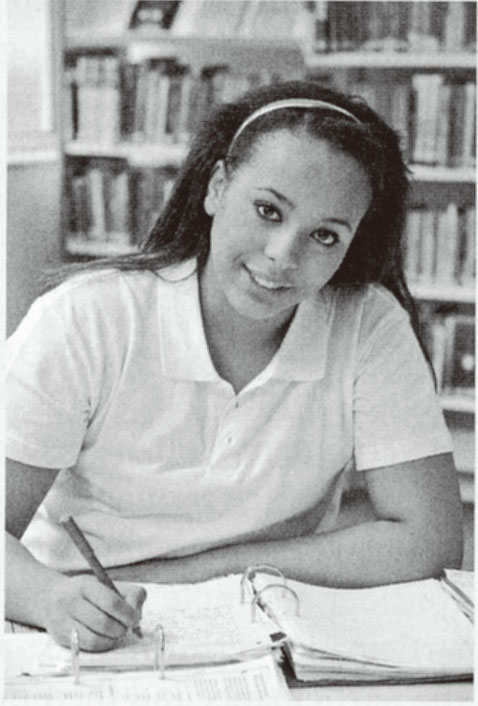

正如我们在后续各章将要看到的，上述学习策略确实能使人更好地记住知识。

◎认识到人类的认知可以是科学研究而不光是哲学思辩的对象还不到150年。

### 德国的心理学：聚焦于内省观察

心理学作为一门科学，标志其诞生的时间通常被认为是1879年，那一年威廉·冯特（Wilhelm Wundt）在德国莱比锡大学建立了第一个心理学实验室。尽管冯特在许多学科上见识广博，但是他的心理学却是认知心理学（而不是心理学的其他主要学科，譬如说比较心理学、临床心理学和社会心理学等）。冯特、他的学生以及众多早期心理学家都采用了被称为内省法 （introspection）的研究方法。在这个方法中，经过充分训练的观察者要在严格控制的条件下报告自己的意识内容。基本的信念是，心理运行的方式应当对自我观察开放。基于英国哲学家的经验主义，冯特等人认为非常深入细致的自我观察应该能够看到思维产生的基本历程。因此，要形成认知的理论，心理学家只需解释内省报告的内容即可。

让我们来考察一个内省实验的例子。迈耶尔和奥思（Mayer & Orth，1901）让被试去执行一项自由联想任务。主试向被试说一个词，然后测量后者对该词作出反应所花的时间。接着被试报告从刺激呈现的瞬间到做出反应的瞬间他们的全部意识体验。为了感受这种方法，请给出下列每个词所对应的一个联想词；每次作出联想之后，试图思索从读到该词到作出联想的过程中，你的意识内容是什么。

外套

书

小圆点

碗

在迈耶尔和奥思的实验中，许多被试都诉说有着难以言表的意识经历。不管存在于意识之中的是什么，它似乎并不总是涉及被试所习惯报告的感觉、表象或其他的具体体验。这个结果引发了一场关于无形象思维的争论——意识经历是否真的可以不具备具体的内容。我们在第4章和第5章中将会看到，现代认知心理学已经在这个问题上取得了实质的进展，但是并非通过内省的方法。

◎在19世纪到20世纪的世纪交替之际，德国心理学家们试图用内省法来研究心理活动。

### 美国的心理学：聚焦于行为

冯特的内省心理学在美国没有得到普遍的认可。早期的美国心理学家致力于他们所谓的“内省”，但是，这种“内省”不是德国人的那种对心理内容进行的深入细致的分析。相反，它在很大程度上更像是一种只有空谈的副业。在这种“内省”中，自我观察仅仅是随意的和反思性的，而不是深入的和分析的。威廉·詹姆斯的《心理学原理》一书（William James，Principles of Psychology ，1890）反映了这一传统的最有价值的贡献。这本书中的许多主张至今仍具有现实意义并令人信服。美国的这种学术氛围是由实用主义和机能主义的哲学信条决定的。那时许多心理学家的工作与教育有关，需要的是一种可实际应用的“行动导向”的心理学。当时的美国心理学界不能接纳专注于意识内容能否被感觉到这类问题的心理学。

美国早期科学心理学的一个重要人物是爱德华·桑代克（Edward Thorndike）。他形成了一种可直接应用于课堂的学习理论。桑代克对奖惩对学习速度的影响这类基本问题感兴趣。对他来说，意识经验只是基本上可以置之不顾的累赘。他不时地用诸如猫之类的动物做实验。对动物进行研究要比对人进行研究较少受到伦理方面的约束。或许使得桑代克同样高兴的正是这些动物被试不会内省。

在上一个世纪之交，当内省法在美国一直得不到重视时，它在欧洲大陆也不断遇到麻烦。各式各样的实验室相继提出不同类型的内省，每一种类型都和提出它的实验室的理论相匹配。事情变得越来越清楚，内省法未能向人们提供一扇可以清楚地观察心理活动方式的窗口。许多对认知运作来说很重要的过程并没有出现在意识经验中。这样两个因素——内省法的“不相关”（“irrelevance”）和它明显的矛盾性——为1920年前后美国心理学界的行为主义大革命奠定了基础。约翰·华生（John Watson）和其他行为主义者们不仅对内省主义，而且对任何发展心理操作（mental operations）理论的尝试都进行了猛烈的抨击。行为主义 （behaviorism）主张心理学完全关注于外在行为，而不是试图去分析作为行为基础的心理活动方式：

行为主义声明意识既不是一个明确的概念，也不是一个有用的概念。作为训练有素的实验家的行为主义者更进一步强调，相信意识的存在意味着倒退到迷信和巫术的远古时代。（Watson，1930，p．2）

行为主义者将所有中世纪的概念清除到一边，开始推出他们自己对心理学问题的系统陈述。他们将诸如感觉、知觉、表象、欲望、目的甚至思维和情绪等所有主观术语全部从科学词汇中删除掉，因为它们都是主观界定的。（Watson，1930，pp．5-6）

行为主义者的纲领及其所产生的后果把对认知的研究推到了美国心理学的幕后。大鼠取代人成为实验室的主要被试，而心理学则转向了通过研究动物的学习和动机，去发现什么是可以学习的。研究者取得了很多发现，但是很少有直接与认知心理学相关的。行为主义最重要的持久性的贡献或许在于：它为包括认知心理学在内的整个心理学领域创建了一套精细而严格的实验研究的技术和原则。

行为主义在欧洲并未取得统治地位。英国的弗雷德里克·巴特利特（Frederick Bartlett）、俄罗斯的亚力山大·卢里亚（Alexander Luria）和瑞士的让·皮亚杰（Jean Piaget）等心理学家所遵循的学术思想对现代认知心理学起着重要的作用。在德国，认知心理学曾是热门课题，但是其中多数已在纳粹肆虐期间销声匿迹了。许多德国心理学家移居到了美国并带来了格式塔心理学 （Gestalt psychology）。 <sup>(3)</sup> 格式塔心理学认为脑和心理的活动大于其各部分的总和，这种观点与德国盛行的内省主义相冲突。在美国，格式塔心理学家发现他们的这种观点以及他们对心理结构的关注同样也与行为主义相冲突。虽然一些格式塔心理学家变得非常有名，例如，格式塔心理学家沃尔夫·科勒（Wolfgang Kohler）曾当选为美国心理学会主席，然而在美国，格式塔心理学家最受关注是因为他们关于动物学习的观点，以及他们是行为主义者理所当然的批评对象。埃德华·托尔曼（Edward Tolman）虽然不是格式塔心理学家，但他是一位从事动物学习研究的美国心理学家，并且预见性地提出了许多现代认知心理学的观点。虽然他使用的是行为主义的语言，但他的观点还是主流行为主义心理学家经常批评的对象。

回顾往事，实在难以理解美国的行为主义者怎么能够采取这种反心理的立场，并且坚持那样长的时间。仅仅因为内省法被证明是不可靠的，并不意味着发展关于内在心理结构和过程的理论是不可能的，它只是意味着需要用其他的方法。例如，尽管原子结构只能被推断出来而不能被直接观察到，物理学仍然发展了原子结构的理论。然而，行为主义者却主张，内部结构的理论对于理解人的行为并不是必要的。从某种意义上讲，他们可能是正确的（参见Anderson & Bower，1973，pp．30-37）。然而，一种内部结构的理论会使得理解人类变得更加容易。现代认知心理学的成功表明，理解心理的结构和过程对理解人类认知是至关重要的。

在内省主义者和行为主义者的纲领中，我们都可以看到人为了解自身所做的不懈努力。内省主义者对自我观察的能力有一种朴素的信念。行为主义者则如此害怕被主观假象所欺骗，以至于他们拒绝考虑内心的过程。现代认知心理学家对待主观的问题则要从容得多，他们采取一种相对超然的态度对待人类的认知，像对待任何其他复杂系统那样地研究它。

◎曾在20世纪上半叶统治美国心理学的行为主义，拒绝用对心理加工过程的分析来解释行为。

### 认知革命：人工智能、信息论和语言学

正如今天人们所知道的，认知心理学形成于20世纪50～70年代的二十年间。在此期间，认知革命推翻了行为主义。三个主要的影响导致了认知心理学的现代发展。第一个方面是在第二次世界大战期间急剧增长的人类工效的研究。当时政府急需关于如何训练士兵使用复杂先进的装备和解决在压力下注意力溃散这类问题的实用知识。行为主义对此类实际问题提供不了帮助。尽管战争期间的研究有一种很实用的倾向，但是战后，相关的问题依旧被心理学家们带回到自己的学术研究实验室。在剑桥大学的应用心理研究组（Applied Psychology Research Unit），英国心理学家唐纳德·布罗德本特（Donald Broadbent）所做的工作，在将人类工效研究中的思想与信息论领域所发展的新思想相结合方面，很可能是最具影响力的。信息论是分析信息处理过程的一种抽象方法。布罗德本特和其他心理学家，比如乔治·米勒（George Miller）、弗雷德·阿特尼（Fred Attneave）和温德尔·加纳（Wendell Garner）最先在知觉和注意方面发展了这些思想。现在这种分析贯穿了所有的认知心理学。

第二个方面是与信息处理方法密切相关的计算机科学的发展，尤其是试图使得计算机有智能化行为的人工智能的发展。艾伦·纽厄尔（Alien Newell）和赫伯特·西蒙在卡内基·梅隆大学花了40年时间向认知心理学家们介绍人工智能的意义（同时也向人工智能工作者们介绍认知心理学的意义）。计算机的理论对认知心理学的直接影响总是微乎其微，但是，其间接影响却是巨大的。计算机科学的大量概念被心理学理论所采用。也许更重要的是，观察我们怎样分析一部机器的智能行为，使我们在很大程度上从分析我们自己的智能时的各种约束和误区中解放出来。

第三个影响认知心理学的是研究语言结构的语言学 （linguistics）。在20世纪50年代，诺姆·乔姆斯基（Noam Chomsky），麻省理工学院的一位语言学家，开始构思一种分析语言结构的新模式。他的工作表明语言比人们先前所认为的要复杂得多，并且当时流行的许多行为主义的理论并不能解释这些复杂性。事实证明，乔姆斯基的语言分析对于认知心理学家摆脱流行的行为主义观念起了关键性作用。20世纪50年代和60年代初，哈佛大学的乔治·米勒在引起心理学家对这些语言分析的注意，以及指出研究语言的新方法等方面发挥了作用。

从20世纪50年代起，认知心理学得到了迅速的发展。1967年，乌尔里克·奈塞尔的《认知心理学》一书的出版（Ulric Neisser，Cognitive Psychology ，1967）是一个里程碑。这本书赋予了该领域一种新的合法性。该书由占6章的知觉和注意与占4章的语言、记忆和思维所组成。这种章节划分与本书的章节划分形成鲜明的对比。本书只用了2章来介绍知觉和注意，却有11章用于介绍语言、记忆和思维。我的章节划分反映了对高级心理过程的日益重视。奈塞尔的著作之后，另一个重要的事件是1970年《认知心理学》期刊（Cognitive Psychology ）的创办。这一期刊为界定认知心理学的领域做出了贡献。

20世纪70年代，出现了一个被称为认知科学的新的相关领域。它试图融合心理学、哲学、语言学、神经科学和人工智能的研究成果。可以把这个领域看成是随着1976年《认知科学》期刊（Cognitive Science ）的出版而诞生的，它是认知科学学会的主要出版物。认知心理学和认知科学的领域有重叠。总的来讲，认知科学更多地利用了诸如逻辑分析和计算机模拟认知过程等这类方法，而认知心理学则主要依赖产生于行为主义时代的实验技术来研究行为。本书介绍了所有的方法，但是重点还是放在认知心理学的实验方法上。

◎信息论、人工智能和语言学发展的影响使认知心理学摆脱了行为主义。

### 信息加工分析

在上一节介绍的各种因素，如今已汇聚成了一种在认知心理学中占据支配地位的研究人类认知的特定方法——信息加工法 （information-processing approach）。这种方法试图将认知分解成为一系列步骤，通过这些步骤，一种被称为“信息”的抽象实体得到了加工。或许解释这种方法的最好办法是介绍它的一个典型例子。

1966年，索尔·斯滕伯格（Saul Sternberg）描述了一个实验范式并对其作出了很有影响的理论解释。在这个已经被称为斯滕伯格范式 （Sternbergparadigm）的实验中，给被试呈现诸如“3 9 7”这样的少量几个数字并要求被试记在心中，然后，给他们看一个探测数字，问他们这个探测数字是否在其所记忆的数字组中，要求他们尽快地做出回答。例如，9为“3 9 7”数字组的正探测，而6则为负探测。斯滕伯格将记忆组中数字的数量从1变为6，测量被试作出判断有多快。图1.1表示作为记忆组大小的函数的实验结果。数据分别图示为正探测或者叫做目标及负探测或者叫做干扰。被试能够相当迅速地作出这些判断，反应时在400～600毫秒之间，1毫秒（ms）等于千分之一秒。斯滕伯格发现，在判断时间和记忆组的大小之间有近似的线性关系。如图1.1所示，记忆组每增加一个数字，被试将多花大约38毫秒的判断时间。

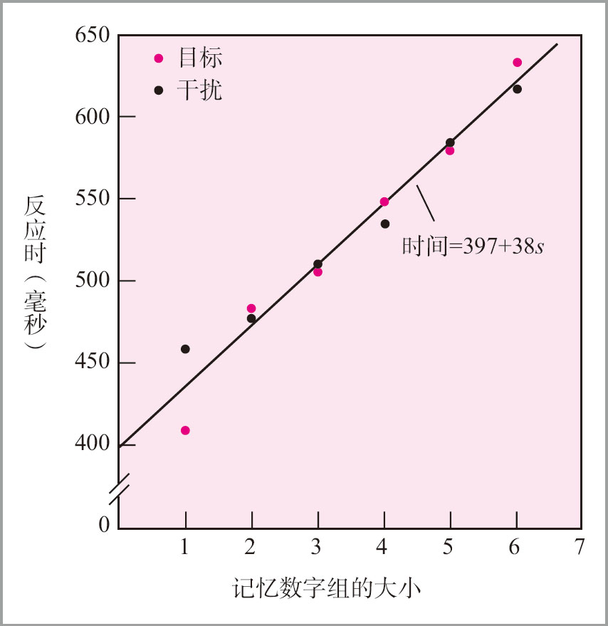

图1.1 识别一个数字所需的时间随记忆组中数字数目的增加而增加。直线表示的是与数据拟合得最好的线性函数。 （资料来源：S．Sternberg，1969．Reprinted by permission of the publisher．©1969 by American Scientist）

斯滕伯格在有关被试如何作出判断上给出了很有影响的解释。这个解释举例说明了抽象的信息加工理论。他的解释见图1.2。斯滕伯格假定当被试看见一个探测刺激如9的时候，他们将会经历图中所示的一系列信息加工步骤。首先这个探测刺激被编码；然后，将这个刺激与记忆组中的每一个数字作比较。斯滕伯格假设，完成每一次比较需用时38毫秒，由此解释了图1.1中直线的斜率。然后，被试必须决定如何反应并做出反应。斯滕伯格指出了不同的变量将会影响这一信息加工过程中的不同步骤。因此，如果他降低探测数字的显示质量，使得它难以分辨，那么，被试就要花较长的时间作出判断。然而，这并不影响图1.1中的直线斜率，因为它只涉及图1.2中知觉刺激这一个步骤。同样，如果他使被试偏向于回答“是”或者“否”，那么作决定的步骤（但不是其他步骤）将会受到影响。

值得注意的是，斯滕伯格理论用例子来说明经典的、抽象的信息加工所使用的方法。

1. 对于所发生的信息加工过程的讨论，不试图根据任何脑部位或脑功能的概念进行解释。
2. 信息加工有很强的符号特征。因此，我们讲的是将符号9与符号3作比较的系统。对这些符号的可能的神经表征不作任何考虑。
3. 斯滕伯格以计算机作比喻来证明他的信息加工理论的合理性。他认为其任务中的信息加工过程可以比作计算机高速扫描的过程。
4. 做一次判断所需时间的长短是关键变量。因为信息加工被设想成是按离散的步骤进行的。图1.2所示的流程图是表达信息加工步骤的非常普遍的方法。流程图本身也是从计算机科学引入的。

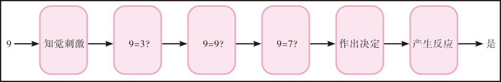

图1.2 斯滕伯格对任务中的一系列信息加工步骤的分析

上述四个特点的每一个都反映出研究人类认知的经典的信息加工方法的局限性。认知心理学家逐渐拓宽他们的方法以处理更复杂的现象，并开始将注意力更多地放在人脑信息加工的本质上。例如，本教材各个版本的演变就是对这种转变的反映。

◎信息加工分析将一个认知任务分解成一系列抽象的信息加工步骤。

### 认知神经科学

认知心理学领域正处在可能像认知革命那样意义重大的变革之中。这种变革主张，在分析几乎所有人类认知功能时都要考虑到人脑的加工过程。一个被称为认知神经科学 （cognitive neuroscience）的领域，致力于研究认知功能在人脑中的实现。认知神经科学的兴起似乎并不使人觉得像一场革命，因为它受到了绝大多数认知心理学家的欢迎。例如，在我们卡内基·梅隆大学的心理学系，认知项目和认知神经科学项目合二为一，因为我们发现大家关注的完全是同样的主题。

知觉的研究（参见第2章）一直有着坚实的生理学基础，而认知的其他要素看起来太复杂以致无法用生理学方法进行研究。然而，随着关于脑的知识的不断增长和研究脑活动的方法的持续发展，这种障碍已逐渐被克服。即使是最复杂的思维过程，现在也有了关于其在脑中如何实现的激动人心的新发现。我将在本章的后面，介绍脑功能成像的新技术。利用各种不同的方法（各有不同的局限性），我们现在能够看到认知是如何在脑中逐渐展现的。作为这一强有力的认知神经科学新技术的一个例子，我将介绍一项涉及求解代数方程的神经活动过程的研究。

就在不久前，上一节中我们所介绍的信息加工方法还被认为与认知神经科学关系不大。但是，现在我们看到了正在发展中的认知神经科学和信息加工分析之间的相互促进。神经科学的数据能用来鉴别信息加工模型，而信息加工模型则能用来整理神经科学的数据。我们在后面讨论解方程的脑成像时将会看到关于后者的一个例子。

◎认知神经科学正在发展能使我们理解认知的神经基础的方法。

## 信息加工：互通讯息的神经元

脑仅仅是神经系统的一部分。完整的神经系统包括搜集来自身体各部位信息的各种感觉系统和控制运动的运动系统。在某些情况下，相当多的信息加工发生在脑之外。按信息加工的观点，神经系统最重要的成分是神经元 <sup>(4)</sup> 。神经元 （neuron）是一种聚积和传导电活动的细胞。人脑大约有1000亿个神经元，其中每个神经元都具有差不多相当于一台小型计算机的处理能力 <sup>(5)</sup> 。1000亿个神经元中有相当大的部分同步活动，大量信息加工是通过彼此交互作用实现的。请想象一下1000亿台交互式计算机的信息处理能力！依据对脑的这种看法，一个3磅重的脑具有比全世界的计算机还要强的计算能力。然而，为防止你过分高估了脑，必须指出的是脑并不善于做某些计算机所擅长的工作。有许多任务，例如求平方根，一个简单的袖珍计算器就能胜过1000亿个神经元。理解人的神经系统的强项和弱点是理解人类认知本质的一个主要目标。

### 神经元

神经元的形状和大小是多种多样的，这取决于它们所处的确切位置和功能（图1.3图示了部分种类的神经元）。但是，神经元有着一个被普遍认可的典型形态，单个神经元或多或少与它相似。图1.4为典型神经元的示意图。神经元的主体叫做胞体。胞体的直径一般为5～100微米（μm）（1微米等于百万分之一米）。胞体上的短分枝被称为树突 （dendrite），而从胞体延伸出的是被称为轴突 （axon）的长管。轴突的长度为几毫米至一米不等。

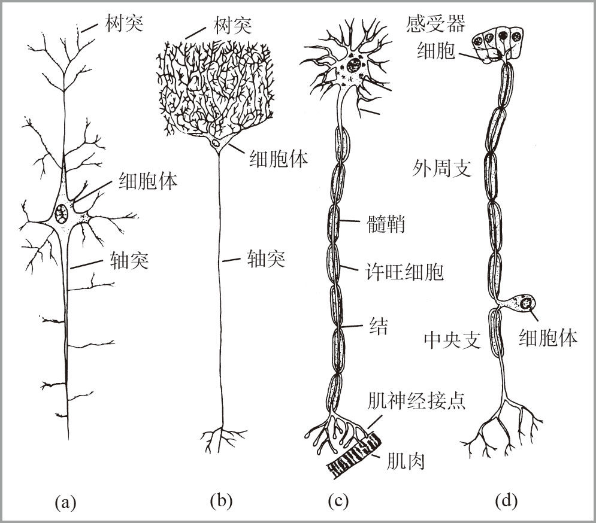

图1.3 部分种类的神经元：（a）锥体（pyramidal）细胞；（b）小脑的浦肯野（Purkinje）细胞；（c）运动（motor）神经元；（d）感觉（sensory）神经元。 （资料来源：Keeton，1980．Reprinted by permission of the publisher．©1980 by W.W.Norton.）

轴突为神经元提供了彼此之间通讯的固定通道。一个神经元的轴突伸向其他神经元的树突。轴突在其端部分叉形成许多树状枝。每个树状枝都在其端部形成终扣，终扣几乎与另一神经元的树突接触。终扣与树突之间的间隙一般在10～50纳米（nm）之间（1纳米等于十亿分之一米）。轴突与树突之间的紧密接触被称为突触 （synapse）。神经元间通讯的典型方式是位于突触一侧的轴突末端释放出叫做神经递质 （neurotransmitters）的化学物质，神经递质作用于树突受体的细胞膜，改变其极性或电位。覆盖整个神经元的细胞膜的内侧与外侧的典型电位差为负70毫伏（mV），因为细胞膜内侧的负离子浓度大于其外侧的正离子浓度。细胞膜外侧高浓度的带正电的钠离子的存在对理解神经元的功能尤其重要。根据神经递质的特性，这个电位差能够升高或降低。使电位差降低的突触被称为兴奋性 （excitatory）突触，而使电位差升高的突触则称之为抑制性 （inhibitory）突触。

胞体和树突平均有大约1000个来自其他神经元的突触，轴突的突触则连向大约1000个其他神经元。任何一个突触引发的电位变化都相当小。然而，单个兴奋和抑制效应却能够累加起来。如果有足够的净兴奋输入，胞体的电位差就会急剧下降。如果电位差下降足够大，去极化将会出现在连接轴突与胞体的轴丘（参见图1.4）。这种去极化是由于带正电的钠离子迅速进入神经元内而造成的。它导致神经元的内侧电位有极短的时间（1毫秒）高于外侧电位。这种被称为动作电位 （action potential）或尖峰脉冲的突变会沿轴突下传。也就是说，沿轴突往下电位差会产生突发的瞬时改变。这种突变的传导速率在0.5米/秒至130米/秒之间，取决于轴突的特性，例如轴突被髓鞘覆盖的程度（髓鞘化程度越高，突变传导得越快）。神经脉冲抵达轴突的末端时，会造成神经递质从终扣处释放，从而完成循环。

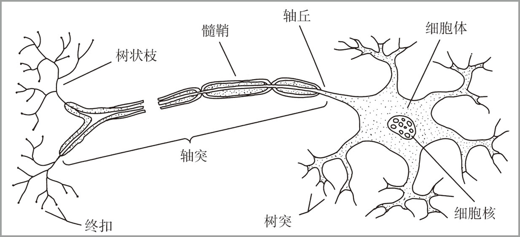

图1.4 典型神经元的示意图。 （资料来源：Katz，1952．Reprinted by permission of the publisher．© 1952 by Scientific American .）

简而言之，电位的改变在细胞体上逐渐积累，当达到阈值时会形成动作电位沿轴突下传。该脉冲进而导致神经递质从轴突末梢传送至另一个神经元并引起它的细胞膜的电位的改变。我想强调的是：这个序列几乎就是神经信息加工的全部。智能就是从这种简单的交互作用系统中产生的。认知神经科学的一个主要的挑战是理解智能的产生机制。

神经通讯完成从一个神经元至另一个神经元的路径需要大约10毫秒——肯定大于1毫秒而小于100毫秒，实际速度取决于有关神经元的特性。这比计算机在1秒钟内执行几百万次运算要慢得多。但是，人脑中同时进行着数以十亿计的这类活动。

◎神经元的通讯是通过突触一侧的轴突末端释放神经递质实现的，这些神经递质作用于树突受体的细胞膜来改变其电位。

### 信息的神经表征

有两个数值对脑中的信息表征特别重要。第一个是细胞膜的电位，它可以是或大或小的负值。第二个是一个轴突每秒传递神经脉冲的数量，这个量叫做轴突的放电频率 （rate offiring），它是可以改变的。一般认为，重要的是沿着一个轴突传递的脉冲的数量而不是脉冲的模式。放电频率可以高达每秒100个神经脉冲。放电频率越高，轴突对与它以突触相连的细胞的影响越大。我们可以将脑的信息表征与计算机的信息表征进行对照。在计算机中单个的存储单元，或位元（bit），只能取断开（0）或接通（1）这两个值中的一个。一个典型的计算机存储单元不能像典型的神经细胞那样连续变化。

总之，有一种方法能从概念上把握神经元间的交互作用，从而解释神经系统中信息传递的许多特殊变化。我们可以设想神经元具有一个大体上与轴突的放电频率或与树突和胞体的去极化程度相对应的激活水平。神经元通过提高其他神经元的激活水平（兴奋）或降低它们的激活水平（抑制）而相互作用。全部神经信息加工都是以这种兴奋效应和抑制效应的方式发生的，它们构成了人类认知的基础。

神经元如何表征信息，这本身就是一个有趣的问题。有单个的神经元对刺激的特定特征作出反应的证据。例如，第2章将要介绍当一条直线以一定角度呈现在视野中时最为活跃的神经元。有些神经元会对更为复杂的特征组合作出反应。例如，猴脑中有一些神经元似乎对面孔的反应最为活跃（Bruce，Desimone，& Gross，1981；Desimone，Albright，Gross，& Bruce，1984；Perrett，Rolls，& Caan，1982）。然而，单个神经元不可能将我们所拥有的全部概念和细微差别的含义进行编码。同时，单个神经元的激发也不能表征面部结构的复杂性。

如果单个神经元无法表达我们认知的复杂性，那么复杂的概念和经历是如何表达的呢？神经元的活动怎样表达我们关于棒球运动的概念？它如何使我们得出代数题的解？它又如何使我们感受到沮丧？我们可以问计算机系统是如何处理这类事情的。计算机系统已经显示出有能力回答有关棒球运动的问题，解代数题，以及表现出沮丧。那么在一台计算机的数百万个处于断开或接通状态的位元中，棒球运动的概念存放何处？一个位元中的变化是如何导致了一个代数问题的解或一种沮丧的感觉？对这些问题的回答是这些问题只见树木不见森林。一项体育运动的概念、一道题的解或一种情绪出现在一些大规模的位元变化的模式中。与此类似，人类的认知也是通过一些大规模的神经活动的模式实现的。一项研究（Mazoyer et al.，1993）比较了听到随机呈现的单词的被试、听到构成无意义句子的单词的被试，以及听到构成条理清晰句子的单词的被试，研究者用下面很快就要介绍的方法测量了脑的活动。他们发现，从听到单词到听到句子再到听到有意义的故事，被试脑中越来越多的区域活跃起来。这一结果表明，我们对有意义的故事的理解涉及许多个脑区的活动。

设想一下计算机是如何存储信息的，便会对我们有所启发。考虑一个简单的例子：词的拼写。大多数计算机都有将二进制数值（1和0）构成的模式表示字母的编码。表1.1是使用一种叫做ASCII <sup>(6)</sup> 的编码系统的例子。它给出了用0和1的模式对cognitive psychology（认知心理学）两个词的编码。

与此类似，脑能够以神经活动的模式而不是简单的细胞放电来表达信息。表1.1中的编码包括冗余位元，它使得一旦有某些位元丢失时计算机能够纠错（注意，表中每一列都有偶数个数字1，它反映了为冗余所增加的位元）。和计算机一样，脑对信息的编码似乎也是有冗余的。它使得即使一定的细胞受到损伤，脑仍能确定模式的编码对象是什么。一般认为，脑所使用的信息编码和实现冗余的系统与计算机中所采用的完全不同。并且，脑似乎采用了比计算机所使用的冗余度高得多的编码，因为单个神经元的行为并不特别可靠。

表1.1 用带奇偶校验的7比特ASCII码来编码的COGNITIVE PSYCHOLOGY

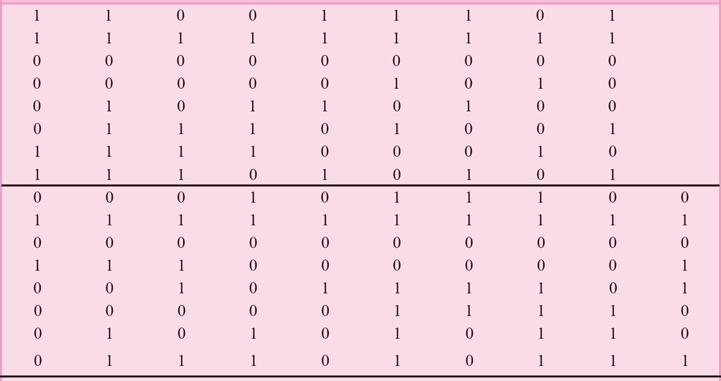

到目前为止，我们仅仅讨论了神经活动的模式。然而，这种模式是瞬时的。脑不会将同一模式保持几分钟，更不用说几天了。这意味着神经的活动模式不能对我们关于外部世界的永久性知识进行编码。人们认为记忆通过神经元间突触连接的变化进行编码。通过改变突触连接，脑能使它自己重新生成一定的模式。成年人不会长出大量的新神经元或新突触，但突触的效力可以随经验而改变。有证据表明，在学习过程中突触连接确实会发生变化，包括神经递质释放的增加（Kandel & Schwartz，1984）和树突受体敏感性的增加（Lynch & Baudry，1984）。我们将在第6章中讨论一些这方面的研究。

◎信息是通过众多神经元的活动模式以及使得这些模式得以重新生成的神经元之间的突触连接来表征的。

## 脑的结构

我们已经回顾了神经信息加工的一些基本原理，现在让我们来看看由脑和脊髓构成的中枢神经系统的整体结构。脊髓的主要功能是将各种神经信息从脑传送至肌肉以及将各种感觉信息从身体传送回脑。图1.5为脑的剖面图，其中标注了一些主要的神经结构。脑较靠下的部分是进化过程中较早的部分，脑较上面的部分是只有高等生物才充分发展了的部分。

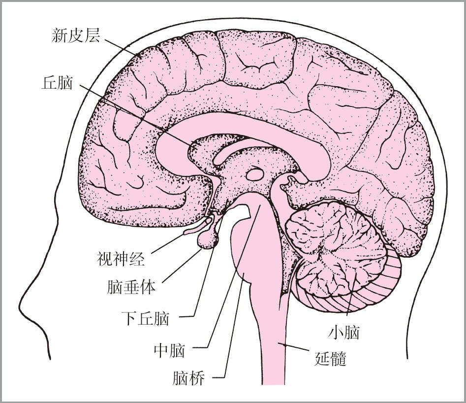

图1.5 脑的纵剖图，图中显示了脑的主要组成部分 （资料来源：Keeton，1980，Reprinted by permission of the publisher ©1980 by W.W．Norton）。

相应地，脑较下的部分承担着比较基本的功能。延髓控制呼吸、吞咽、消化和心跳。下丘脑管理着基本欲望的表达。小脑在运动协调中起着重要的作用。丘脑起着中继站的作用，用来将运动和感觉信息从较低的区域传递至皮层。正如我们将在后面进行探讨的，虽然小脑和丘脑承担这些基本功能，但是，它们在人的高级认知方面也起着重要的作用。

大脑皮层，或者叫新皮层，是脑中最新进化出来的部分。大脑皮层虽然在许多哺乳动物中非常小且原始，但对于人脑来说它却是一个比例很大的部分。在人脑中，大脑皮层可以看成是表面积约为2500平方厘米的相当薄的神经组成的皮层。为了使这块神经皮层容纳于颅骨内，它必须是高度折叠的。有着大量折皱的大脑皮层是人脑与低等哺乳动物的脑之间显著的物理差别之一。皮层向外突出的部分称为脑回 （gyrus），而脑回之间的皱褶称为脑沟 （sulcus）。

新皮层分为左右两个半球。解剖学上有趣又令人称奇的是身体的右半部分往往是与脑的左半球连接，而身体的左半部分则往往与脑的右半球连接。因此，脑的左半球控制右手的运动和感觉。右耳与左脑半球联系最强。每只眼睛中接收从视野左侧输入的刺激的神经感受器都连接到右脑半球（下一章的图2.5和2.6将对此进行解释）。

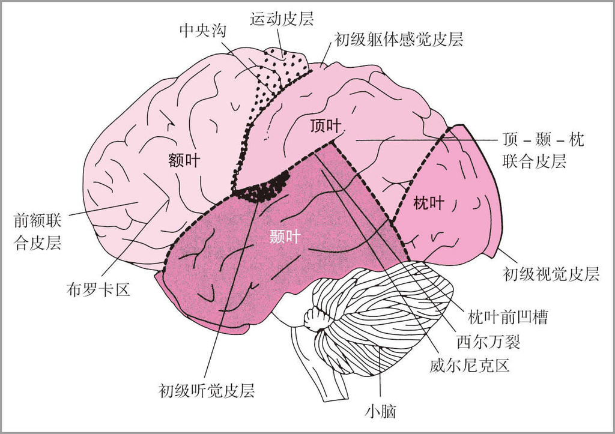

图1.6 大脑皮层的侧视图，图中显示出每个脑半球的4个脑叶，即额叶、枕叶、顶叶和颞叶（着不同深度红色的区域），以及大脑皮层的其他主要组成部分。 （资料来源：Kandel & Schwartz，1984，Reprinted by permission of the publisher © 1984 by Elsevier）

然而，我们不能因此认为只有新皮层才在高级认知中扮演重要角色。脑中有许多由皮层至皮层下结构再返回皮层的重要回路。经证实，一个对记忆极其重要的区域是位于大脑皮层和下层结构之间的边界处的边缘系统。边缘系统包含一个叫做海马 （hippocampus）的结构（位于颞叶内部），它看来对人的记忆至关重要。遗憾的是，在如图1.5那样的纵剖视图中无法显示海马，因为海马是在左右两个脑半球的内部，位于表层与脑的中心之间的结构。图1.7是海马及其相关结构的示意图。正如我们将在第7章所见，损伤海马及其邻近结构将导致严重的健忘症。

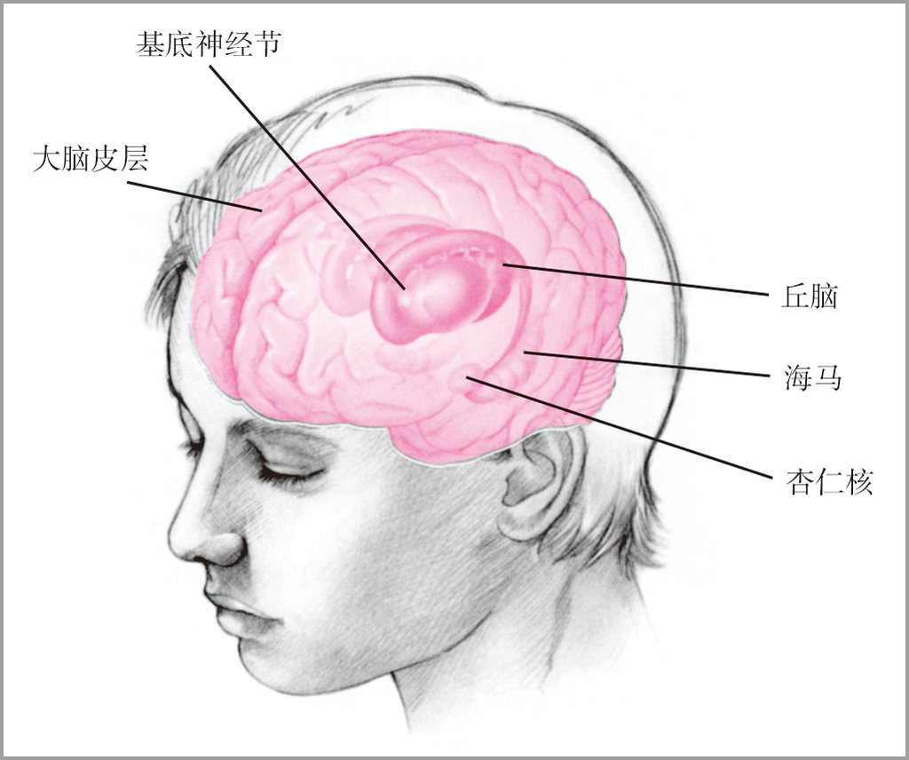

图1.7 边缘系统的部分皮层下结构，包括海马在内（红色标注）。图中也标出了相关结构。 （资料来源：Gluck，Mercado，& Myers，2008.图2.3.）

另一组重要的皮层下结构是基底神经节 （basal ganglia）。基底神经节的重要的连接示于图1.8。基底神经节既参与基本运动控制，又参与复杂认知控制。这些结构接收来自几乎所有皮层区域的投射，并且发送投射至前额皮层。诸如帕金森病和亨廷顿病之类的神经疾病是由于基底神经节损伤所致。经受这些疾病之苦的患者不但出现了以颤抖和僵直为特征的明显的运动失控症状，而且他们在完成精细的认知任务方面也存在困难。小脑的主要作用是运动控制，但看来在高级认知过程中也扮演着一个角色。在小脑损伤的患者中已经观察到了许多认知缺失症状。

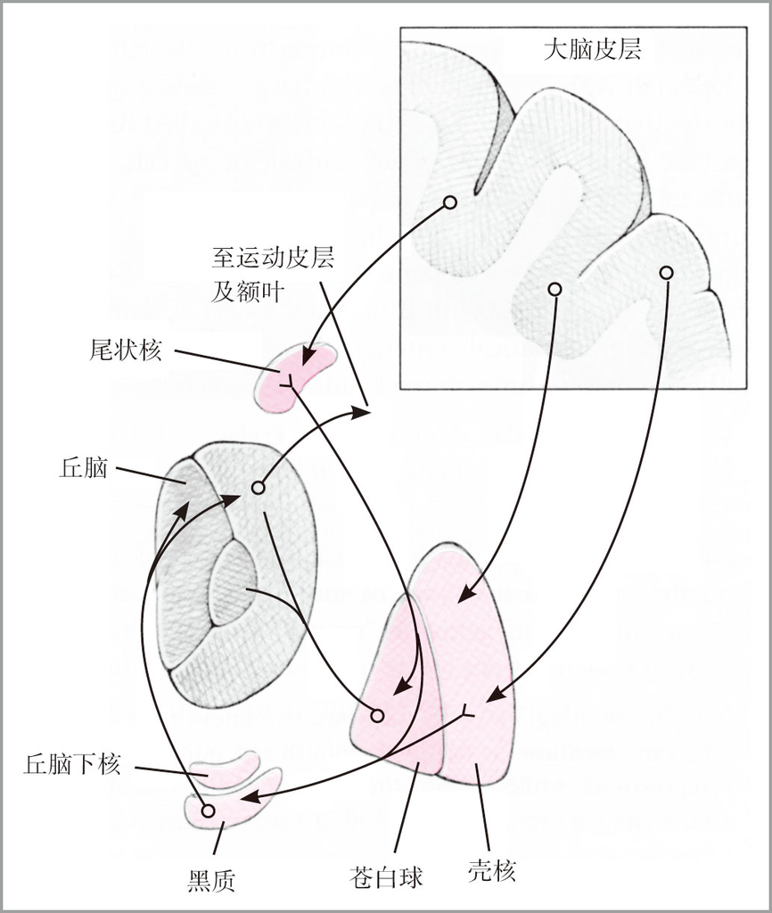

图1.8 基底神经节的主要结构（着不同红色的区域），包括尾状核、丘脑下核、黑质、苍白球和壳核，以及它和大脑皮层的主要连接（输入和输出） （资料来源：Gazzinga et al.，2002．Reprinted by permission of the publisher ©2002 by W．W．Norton）

◎脑由若干个不同的区域所组成，不同的区域执行不同类型的功能。

### 功能定位

我们现在开始了解高级认知功能在脑中出现的位置。两个脑半球显示出对不同类型信息处理的某种程度的专门化。一般而言，左脑半球看起来与语言和分析的信息加工有关，而右脑半球则与知觉和空间信息加工有关。左右两个脑半球由叫做胼胝体 （corpus callosum）的宽厚的纤维带连接。为防止癫痫发作，有些患者做了胼胝体切开手术。这种患者被称为裂脑病人 （split-brain patients）。这种手术一般都很成功，患者看上去相当正常。两个脑半球之间差异的证据大多出自对这些患者的研究。精细的心理学研究已经发现了裂脑病人和未做此类手术的人之间的巨大差异。在一项实验中，钥匙一词闪现在患者正在注视的屏幕的左边。由于该词位于屏幕的左边，因此，它将由非语言的右脑半球接收到。当问在屏幕上出现了什么时，患者无法说出，因为语言占优势的脑半球不知道这个词。但是，该患者的左手（而不是右手）却能从隐藏在视线之外的一组物体中挑拣出钥匙来。

对裂脑病人的研究已经使心理学家能够发现左右两个脑半球各自的功能分工。研究表明左脑半球具有语言优势。例如，指令可以呈现给这些患者的右耳（到达其左脑半球）或左耳（到达其右脑半球）。右脑半球只能理解最简单的语言命令，而左脑半球则显示出完整的领悟能力。与此不同的结果是，当比较右手（左脑半球）与左手（右脑半球）执行动手任务的能力时，右脑半球明显优于左脑半球。

对其他特定脑部损伤病人的研究表明，左脑皮层有称为布罗卡区 （Broca's area）和威尔尼克区 （Wernicke's area）的脑区（见图1.6）。它们看来是负责言语功能的关键脑区，因为损伤它们会造成言语严重受损的失语症 （aphasia）。涉及言语的神经区域可能不仅仅是这两个区域，但是，这两个脑区确实非常重要。不同的言语缺失似乎取决于损伤的是布罗卡区还是威尔尼克区。患有布罗卡失语症（即损伤在布罗卡区）的人说的是短促、不合语法的句子。例如，当问一位病人周末是否开车回家时，他答道：

为什么，是的……星期四，呃，呃，呃，不，呃，星期五……芭-芭-拉……妻子……和，哦，车……开……收费高速公路 <sup>(7)</sup> ……你知道……休息和……电视（Gardner，1975，p．61）

与此相反，患有威尔尼克失语症的病人说的是相当合语法但却几乎是无意义的句子。这种病人有词汇方面的困难并且说的是空话。下面是一位这种病人对“是什么原因让你到医院来的？”这一问题的答复：

哦，我在出汗，我太紧张了，你知道，有时我被抓住，我不能说出tarripoi <sup>(8)</sup> ，一个月前，差不多吧，我做了好多，我施加很多影响，哦，还有，你知道我说的是什么，我必须来回跑，仔细检查，trebbin <sup>(9)</sup> 和所有那些玩意。（Gardner，1975，p．68）

◎脑内不同的专门区域支持不同的认知功能。

### 拓扑组织

在皮层的许多区域，信息加工在空间上形成了一种叫做拓扑组织 （topographic organization） <sup>(10)</sup> 的结构。例如，在皮层后部的视觉区，相邻区域表征了视野中相邻区域的信息。图1.9提供了这一事实的一个例证（Tootell，Silverman，Switkes，& De Valois，1982）。研究者给猴子呈现了如图1.9a的圆窗图形。图1.9b为记录在枕叶皮层上的激活图形，它是通过注射一种可标记神经活动最强的位置的放射性材料而获得的。我们看到圆窗结构被复制出来，其中只有少许的畸变。类似的组织原理支配着身体部位在运动皮层和躯体感觉皮层中沿中央沟的表征。身体的相邻部分表征在相邻的神经组织中。图1.10表示了沿躯体感觉皮层的人体表征。请注意，图中的身体是变形的。有些区域得到明显的过度表征。结果是这些过度表征的区域对应着身体比较敏感的地方。因此，例如，相比背和大腿，我们的手和脸能够辨别出更细微的触觉刺激的差异。再如，视觉中心处的视野在视觉皮层中被过度表征，因此我们视觉中心的精确度最高。

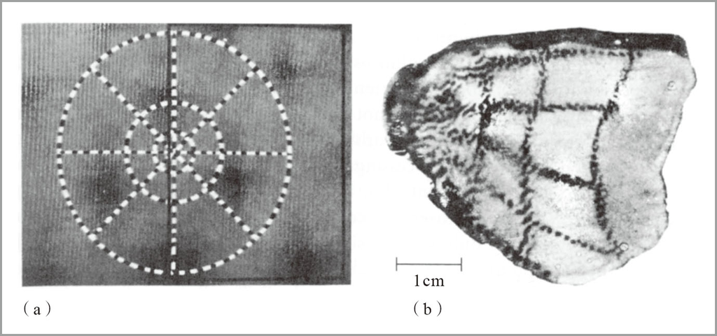

图1.9 拓扑组织的证据。视觉刺激（a）呈现给猴子，刺激导致了猴脑的激活模式（b）。这一模式与刺激的结构非常匹配。 （资料来源：Tootell et al.，1982．Reprinted by permission of the publisher．©1982 by American Association for the Advancement of Science.）

[figure not shown]

图1.10 躯体感觉皮层的横断面图，显示了人的身体是如何映射到神经组织的。 （资料来源：Kandel & Schwartz，1984．Reprinted by permission of the publisher．© 1984 by Elsevier.）

有种观点认为，拓扑图的存在使加工相似区域的神经能够彼此间互相作用（Crick & Asanuma，1986）。虽然大脑的不同区域之间有纤维相连，但是神经元主要还是和邻近的神经元相连接。也就是说，局域连接不仅使神经元之间的通讯时间最小化，而且也使将其连接在一起的神经组织的数量最小化。局域化的极端情况是皮层微柱（Buxhoeveden & Casanova，2002）——大约100个神经元组成的功能非常有限的微小的垂直柱状结构。例如，初级视觉皮层中的皮层柱专门负责加工来自一只眼睛的一个位置的一个方向的信息。

皮层微柱中的神经元并非代表一个极其精确的位置，而是一定范围的邻近区域。它与神经信息加工的另一个特点粗糙编码有关。单个神经元似乎对应着一定范围的事件。例如，当躯体感觉皮层的单个神经元的神经活动被记录下来时，我们可以看到它并不只是在身体的某一个点受到刺激时做出反应，而是当身体不算小的一小块区域中的任何一点受到刺激时都做出反应。那么，我们如何才能准确地知道哪一点被碰触了呢？这个信息被非常精确地记录了下来，但并不是基于任何一个特定细胞的反应，而是不同的细胞将对身体中不同的重叠区域做出反应。身体中的任何一点都会激活一个细胞群，不同的点激活不同的细胞群。因此，一个点的位置是由激活模式所反映的。这个事实支持了神经信息往往由激活模式所表征这一观点。

◎皮层中相邻的细胞倾向于处理来自身体邻近区域的刺激。

## 认知神经科学的方法

为了理解认知的神经基础，人们是怎么做的呢？过去许多神经科学方面的研究是在动物身上进行的。其中有些研究涉及到用手术切除皮层的不同部分。通过观察这些手术造成的行为缺损，有可能推断出这些被切除区域的功能。另外的研究记录了特定神经元或神经元区域的电活动。通过观察是什么激活了这些神经元，可以推断出它们在做什么。但是，从动物身上得出的结论在多大程度上能推广到人类身上还很难说。人类的认知能力和大多数其他动物有着巨大的差异。除其他灵长目动物外，即使是让其他动物从事有人类特征的认知过程都非常困难。这就造成了通过动物实验理解高层次的人类认知的神经基础的巨大障碍。

直到最近，对患者群的研究仍然是理解脑在人类认知中的作用的主要基础。我们已经介绍了这方面的一些研究，例如，对裂脑病人的研究和对中风导致语言障碍患者的研究。正是对患者群的研究，揭示了人脑是单侧化的，左脑半球侧重于语言加工。这种脑半球的专门化没有出现在其他物种中。

近年来，对参加各种认知活动的正常被试实施无创伤脑功能成像的方法有了重大进展。在神经成像方面的进展是认知神经科学最振奋人心的发展之一，在本书中它将不断地被引用。这些方法的精度已经得到了大幅度的改进，尽管它不如记录单个神经元那样精确，但是对人进行单细胞记录只有在极少的情况下才能实施（而且是外科手术过程的一部分）。

脑电图 （electroencephalography，EEG）记录头皮上的电位。当大群体的神经元激活时，它们的电活动会在头皮上产生独特的电位模式。典型的做法是，被试戴上一顶装有多个电极的帽子。这些电极将检测电活动的有节律的变化，并将其记录在脑电图上。图1.11显示了不同认知状态下的典型记录。用EEG研究认知时，将要求被试对一些刺激做出反应，研究者的兴趣是发现对这些刺激的加工如何影响所记录的总体电活动。为了排除刺激之外的效应，需对许多次测试 <sup>(11)</sup> （trial）进行平均。平均之后的结果便是由刺激所产生的电活动。例如，库塔斯和希利亚德（Kutas & Hillyard，1980a）发现，在被试听到句子中的一个意外词大约400毫秒后，出现了一个振幅为负值的大波（我将在第13章作进一步讨论）。这种针对某个特定刺激作出反应的平均EEG被称之为事件相关电位 （event-related potentials，ERPs）。ERPs具有很好的时间分辨率，但是要推断出产生头皮电活动的神经活动在脑中的位置则是困难的。

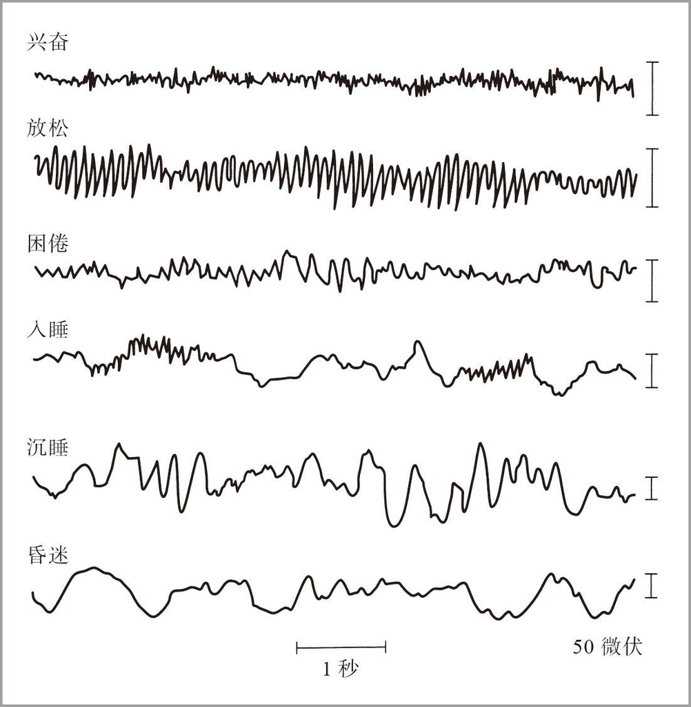

图1.11 不同意识状态下的脑电图曲线。 （资料来源：Kolb & Whishaw，1996；after Penfield & Jasper．1954．Reprinted by permission of the publisher ©1996 by W．H．Freeman.）

ERP新近的一种变体是脑磁图 （magnetoencephalography，MEG），它提供了更好的空间分辨率。脑磁图记录了电活动所产生的磁场。因为所测量的磁场的特性，它最适合探测皮层的脑沟活动，而对脑回和脑的深层部位的活动不太敏感。

下面我们将讨论两种方法，正电子发射断层扫描 （positron emission tomo-graphy，PET）和功能性磁共振成像 （functional magnetic resonance imaging，fMRI），它们在确定神经活动的位置方面的能力相对较强，但是在确定神经活动的时间进程方面的能力相对较差。无论是PET还是fMRI都不是直接测量神经活动。相反，它们测量的是脑中不同区域的新陈代谢率或血流量。其所依据的事实是，脑中越是活跃的区域，其所需的新陈代谢消耗就越大，通过的血流量也越大。它们可以被看成是对某个脑区的工作量的测量。

在做PET时，要将一种放射性示踪物质注射至人体的血流中（在典型的PET中，放射性照射的剂量相当于两次X射线胸部透视的剂量，因而并无危险）。被试被安置在一台PET设备中，该设备能够检测出放射性元素含量的变化。目前的方法可达到5～10毫米的空间分辨率。例如，波斯纳和彼得森等人（Posner，Peterson，Fox，& Raichle，1988）采用PET通过观察人脑有哪些区域参与了单个单词的阅读来给阅读过程的各个成分进行定位。图1.12为他们的研究结果。皮层上的三角形表示被试在被动地注视具体名词时，脑的活跃区域。正方形则表示要求被试想出这些名词的用途时变得活跃的区域。三角形位于枕叶，正方形位于额叶。因此，这些数据表明，视觉知觉到一个单词的过程与思考一个单词的意义的过程发生在脑的不同部位。

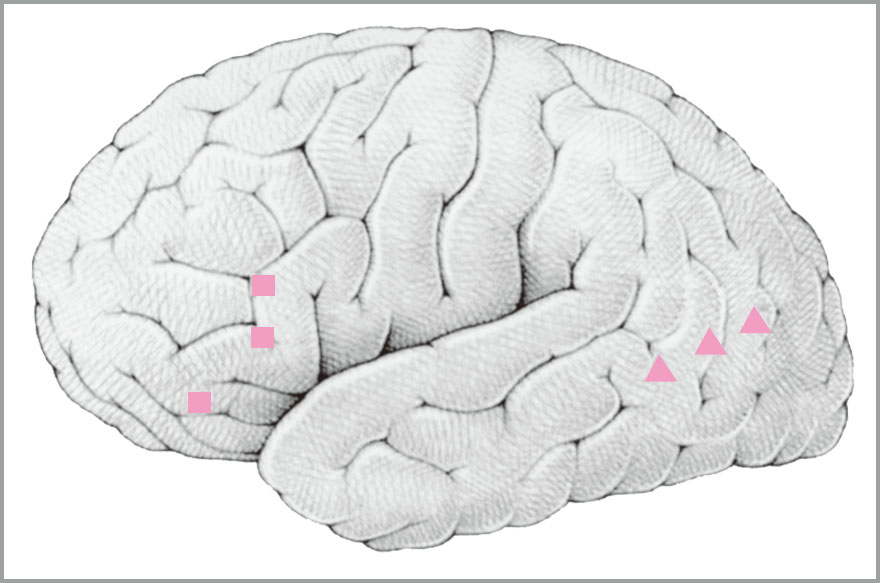

图1.12 从皮层的侧面看由视觉单词阅读激活的区域。三角形表示由被动视觉任务激活的位置，正方形表示由语义任务激活的位置。 （资料来源：Posner et al.，1988．Reprinted by permission of the publisher．©1988 by American Association for the Advancement of Science.）

fMRI已经在很大程度上取代了PET。fMRI甚至提供了比PET更佳的空间分辨率与更低的侵入性。fMRI采用了与磁共振成像（MRI）相同的扫描设备，目前MRI已成为医院扫描患者各种结构包括脑结构在内的标准设备，稍作改动，它就可以用来进行脑功能成像。fMRI无须向被试注射放射性示踪药物，其依据的事实是神经活动越活跃的区域，其氧合血红蛋白越多［有人可能认为较强的活动会耗尽氧，而事实是，身体对此作出了过度的补偿反应，结果反而增加了血液中的氧——这被称为血流动力学反应 （hemodynamic response）］。无线电频的电磁波被发送，穿过脑并使血红蛋白中的铁产生局域磁场，该磁场可用安置在头部周围的磁传感器探测到。因此，fMRI提供了一种测量特定脑区所消耗能量的手段：神经活动较强的脑区域信号较强。fMRI优于PET的特点包括，无须注射放射性物质，因而能允许较长时间的测量，此外它提供了较高的时间和空间的分辨率。下一节我将详细介绍一项fMRI的研究来说明它的基本方法以及它能做些什么。

无论是PET还是fMRI都不是实用的、可每天用来测量的方法。就连较为实用的fMRI也要用价值数百万美元的扫描设备，并且要求被试一动不动地躺在噪声不断又令人感到不舒适的封闭黑暗的空间内。然而，更为实际的技术将有希望成为可能。一种比较有前途的方法是近红外检测技术（Strangman，Boas，& Sutton，2002）。这种方法的原理是光线可以穿过组织（将一只手电筒放在你的手掌下可以演示这一点）并被反射回来。在近红外检测技术中，将光线照射在颅骨上，然后用设备检测反射光的光谱。结果发现，近红外光趋向于不被氧合组织所吸收，这样，通过测量近红外区光线的光通量（该光线无法被人的肉眼看到），人们就能检测到脑部特定区域中血液的氧合情况。这种方法有望比PET或fMRI廉价得多且局限性较小，而且不需要限制被试的头部活动。甚至现在这项技术就已经被用于无法确保不动的幼儿和无法控制自己运动的帕金森病患者。这种技术的主要局限是它只能探测到脑内2～3cm的活动，这是光波能有效穿透的距离。

虽然这些各种各样的成像技术彻底改变了我们对人类认知的探索，但是它们各有其局限性。除了在空间和时间分辨率上各有不同的局限性外，它们还难于做出因果推论。仅仅因为探测到人在执行一项任务时某个脑区的激活，并不能说明这一区域就是执行该任务的关键。直到最近，我们还不得不从对脑中风、脑损伤和脑病变的病人的研究来确定某个脑区的重要性。但是，现在已经有了新的能够暂时抑制一个脑区的方法。其中最主要的一种方法称为经颅磁刺激 （transcranial magnetic stimulation，TMS），在使用中将一个线圈置于头颅的特定位置并将脉冲传送到这个区域（见图1.13），使得线圈下的脑区的功能受到干扰。只要操控得当，TMS是安全的而且没有持久影响。它可以有效地确定不同脑区的作用。例如，当被试试图学习、记忆一个项目时，前额叶和顶叶都有所激活。然而，当TMS作用于前额叶（Rossi & nbsp；et al.，2001），而不是作用于顶叶时（Rossi et al.，2006），则会干扰记忆的形成。这就意味着前额叶在记忆形成的过程中起到了更为关键的作用。

[figure not shown]

图1.13 经颅磁刺激产生于放置在头上的一个线圈。这个线圈产生短暂但强有力的磁脉冲，磁脉冲导致脑表层的一个小区域出现瞬时电流。瞬时电流会以高度的时间精度和良好的空间精度干扰脑的加工功能。 （Sabine Kastner提供）

◎EEG、MEG、fMRI和TMS等技术使得研究人员可以研究人类认知的神经基础，其精度开始逼近动物实验。